# Polycaprolactone and poly(vinyl alcohol) electrospun single-layer nanofiber materials loaded with novel antibacterial LEGO-LPPO for advanced wound dressing

- Show All Code
- Hide All Code
- View Source

Figure 9 - Statistical report

Author

Nitjawan Sahatsapan, Jana Sabová, Ivana Kóšiová, Maxim Lisnenko, Eva Kuželová Košťáková, Kateřina Bogdanová, Kateřina Pražáková, Eva Dávidová, Viktor Mojr, Kristýna Havlíčková, Šárka Hauzerová, Jana Müllerová, David Sýkora, Marek Kindermann, Elizabeth Tsibouki, Katerina Chudejova, Vendula Peckova, Pavel Klein, Tomáš Urban, Renata Večeřová, Milan Kolář, David Lukáš, Věra Jenčová, Peter Gál, Dominik Rejman

**Authors’ affiliations**:

Nitjawan Sahatsapan<sup>1,±</sup>, Jana Sabová<sup>2,±</sup>, Ivana Kóšiová<sup>1,±</sup>, Maxim Lisnenko<sup>3,±</sup>, Eva Kuželová Košťáková<sup>3,±</sup>, Kateřina Bogdanová<sup>4,±</sup>, Kateřina Pražáková<sup>5</sup>, Eva Dávidová<sup>1</sup>, Viktor Mojr<sup>1</sup>, Kristýna Havlíčková<sup>3</sup>, Šárka Hauzerová<sup>3</sup>, Jana Müllerová<sup>3</sup>, David Sýkora<sup>5</sup>, Marek Kindermann<sup>6</sup>, Elizabeth Tsibouki<sup>7</sup>, Katerina Chudejova<sup>6,8</sup>, Vendula Peckova<sup>6</sup>, Pavel Klein<sup>6,9</sup>, Tomáš Urban<sup>10</sup>, Renata Večeřová<sup>4</sup>, Milan Kolář<sup>4</sup>, David Lukáš<sup>3</sup>, Věra Jenčová<sup>3</sup>, Peter Gál<sup>2,10,11</sup>, Dominik Rejman<sup>1,12</sup>

<sup>1</sup>Institute of Organic Chemistry and Biochemistry, Czech Academy of Sciences, Flemingovo nám. 2, 166 10 Prague 6, Czech Republic.  
<sup>2</sup>Department of Pharmacology, Faculty of Medicine, Pavol Jozef Šafárik University, Košice, Slovak Republic.  
<sup>3</sup>Department of Chemistry, Faculty of Science, Humanities and Education, Technical University of Liberec, Studentská 1402/2, 461 17 Liberec 1, Czech Republic.  
<sup>4</sup>Department of Microbiology, Faculty of Medicine and Dentistry, Palacký University Olomouc, Hněvotínská 3, 775 15 Olomouc, Czech Republic.  
<sup>5</sup>University of Chemistry and Technology Prague, Department of Analytical Chemistry, Technická 5, 166 28 Prague 6, Czech Republic.  
<sup>6</sup>Biomedical Center, Faculty of Medicine in Pilsen, Charles University, Czech Republic.  
<sup>7</sup>Faculty of Medicine in Pilsen, Charles University, Czech Republic.  
<sup>8</sup>Department of Microbiology, Faculty of Medicine in Pilsen, Charles University, Czech Republic.  
<sup>9</sup>Department of Pathological Physiology, Faculty of Medicine in Pilsen, Charles University, Czech Republic.  
<sup>10</sup>Prague Burn Center, Third Faculty of Medicine, Charles University, Prague, Czech Republic.  
<sup>11</sup>Department of Biomedical Research, East-Slovak Institute of Cardiovascular Diseases, Ondavská 8, 040 11 Košice, Slovak Republic.  
<sup>12</sup>University of Chemistry and Technology Prague, Department of Chemistry of Natural Compounds, Technická 5, 166 28 Prague 6, Czech Republic.

**Report author**:  
[Marek Kindermann, PhD](https://orcid.org/0009-0002-2074-7833)

**Review & Proofing**:  
[Filip Tichanek, PhD](https://orcid.org/0000-0003-4139-1979)

**Original publication**

This is data analysis report for the [publication](https://doi.org/10.1016/j.bioadv.2026.215039) *Polycaprolactone and poly(vinyl alcohol) electrospun single-layer nanofiber materials loaded with novel antibacterial LEGO-LPPO for advanced wound dressing*.

When using this code, cite original publication:

Sahatsapan, Nitjawan, et al. “Polycaprolactone and poly (vinyl alcohol) electrospun single-layer nanofiber materials loaded with novel antibacterial LEGO-LPPO for advanced wound dressing.” Biomaterials Advances (2026): 215039.

Original GitHub repository: https://github.com/KindermannMarek/LPPO_preventSA.git  
Archived version (Zenodo DOI): https://doi.org/10.5281/zenodo.19368428

# 1 Introduction

The goal of this analysis, as visualized in Figure 9 ([original publication](https://www.sciencedirect.com/science/article/pii/S2772950826003377)), is to understand how different treatments affect the healing process of infected wounds, as measured by a visual score ranging from 0 (best) to 3 (worst). We also want to see how the final amount of bacteria in the wound (final bacterial load) associates with this visual score.

Statistical analyses were performed using R, version 4.5.1 (R Core Team 2021) within the Quarto publishing framework (Allaire et al. 2025). Bayesian multilevel modeling was implemented via the brms package, version 2.23.0 (Bürkner 2017), which interfaces with Stan for Hamiltonian Monte Carlo sampling (Stan Development Team 2025). Model results were visualized and processed using the tidyverse, v2.0.0 (Wickham et al. 2019) suite of packages. The reporting format (YAML header) and computational workflow were adapted from the validated pipeline previously established by (Zahradka et al. 2024) in this [statistical report](https://filip-tichanek.github.io/CovidTimeRTX/).

## 1.1 Notation and formatting conventions

To ensure clarity, we employ the following formatting conventions to distinguish between mathematical variables, model-specific parameters and R objects:

- $mathematical \ notation$: Formal mathematical variables and theoretical parameters are written in LaTeX italics. For example, $\beta_{logCFU}$ represents a specific population-level effect in a theoretical context.
- $\color{pink}{\text{brms model coefficients}}$: Coefficients and parameters generated directly by the brms model are highlighted in pink using LaTeX formatting. This distinguishes the estimated output from the theoretical variable. For example, $\color{pink}{\text{Intercept[1]}}$ or $\color{pink}{\text{treatA[2]}}$ refers specifically to the values residing within the posterior distribution.
- `R objects and variables`: Specific programming entities, such as data frame columns (`test_ID`) and saved model objects (`fit1.1.0`).

## 1.2 Data description

### 1.2.1 Experimental design

In one experiment (see `test_ID` variable), there were typically mice from two to three `cage`s, each mouse with specific `ID`. These mice received the same `batch` of bacterial inoculum within the given experiment. The same `batch` of inoculum was applied on both `sites` (left wound; right wound). An experimental treatment (B, H, G) or positive control (Ag) was applied to the left excision wound (immediately after application of the inoculum to the wound); a negative control (A, E, Cosmopor) was applied to the right wound (immediately after application of the inoculum to the wound). After undressing (after one week), the wounds were visually assessed (`score`) and a sample was taken using a microbiological loop to obtain `CFU_mL` (microbiological assessment).

### 1.2.2 Visual score

`score`: evaluation of visual observation of the wound after treatment application (one week after application); - 0: wound physiologically healing or partially healed, no visible presence of infection and/or inflammation; - 1: slight presence of purulent material - 2: purulent material is present, not exceeding the boundary of the wound bed - 3: wound bed is filled with bacterial biofilm, inflammatory skin reaction is visible in the immediate vicinity of the wound - 4 - wound dehiscent, completely filled with bacterial biofilm, which is also located outside the original wound boundaries, inflammatory skin reaction is visible even several mm from the original location of the wound bed

Because the score 1 was underrepresented in the dataset, we have merged the original scores 1 and 2 into a new score 1. The modified scoring system used for the analysis (and manuscript) is as follows:

`score2`: evaluation of visual observation of the wound after treatment application (one week after application); - 0: wound physiologically healing or partially healed, no visible presence of infection and inflammation; - 1: purulent material and/or inflammation is present; purulent materiel not exceeding the boundary of the wound bed - 2: wound bed is filled with bacterial biofilm, inflammatory skin reaction is visible in the immediate vicinity of the wound - 3 - wound dehiscent, completely filled with bacterial biofilm, which is also located outside the original wound boundaries, inflammatory skin reaction is visible even several mm from the original location of the wound bed

### 1.2.3 Microbiological assessment

`N_colonies`: number of colonies counted on the agar plate after plating the sample from the wound

`TDL`: total dilution level - dilution factor used to dilute the initial sample

`CFU_mL`: final bacterial load in the wound (one week after application), colony-forming unit, which estimates the number of microbial cells per 1 mL in the wound after the treatment

> Calculation of `CFU_mL`:  
> - inoculation loop (1 uL volume) is used to collect the sample from the wound  
> - 200 uL volume used to wash the loop  
> - TDL is dilution factor used to dilute the initial sample (201 uL)  
> - 100 uL of dilluted sample was tested

> CFU_uL = (N_colonies * TDL * 201) / 100  
> CFU_mL = (N_colonies * TDL * 201) / 0.1

`CFU_mL2`: adjusted `CFU_mL` variable where all zero values were replaced with 1005 (limit of detection / 2) to allow logarithmic transformation

> Estimation of the limit of detection (LOD):  
> Smallest countable unit on the plate is N = 1 unit  
> To replace CFU_mL = 0, we set N = 0.5 (no colony-forming unit were detected)  
> For all samples having CFU_mL = 0 is true that TDL = 1

> CFU_mL[new] = (0.5 * 1 * 201) / 0.1 = 1005  
> log10_CFU_mL[new] ~ 3

`log_CFU_mL2`: logarithmic transformation of `CFU_mL2` (base 10)

`log_CFU_mL2_s`: standardized `log_CFU_mL2` variable (mean = 0, sd = 1)

### 1.2.4 Treatment

`treat`: treatments were applied in pairs (1 pair per 1 mouse):

> “B” - “A”  
> “G” - “E”  
> “H” - “E”  
> “Ag” (positive control) - “Cosmopor” (negative control)

where:

> “A” -> NANO_LPPO A  
> “B” -> NANO_LPPO B  
> “E” -> NANO_LPPO E  
> “G” -> NANO_LPPO G  
> “H” -> NANO_LPPO H  
> “Ag” -> PC  
> “Cosmopor” -> NC

### 1.2.5 Grouping variables

`site`: position of the excision wound in the dorsal region, left (L) and right (R)

`ID`: animal ID (specific for each mouse)

`cage`: the mice in the experiment are placed in cages that reflect the mice’s kinships

`batch`: reflects the inoculum batch; One freshly prepared inoculum was used for each experiment

`test_ID`: ID for a single experiment

## 1.3 Causal framework (DAG)

To ensure our statistical analysis aligns with the biological mechanisms of wound healing, we established a Directed Acyclic Graph (DAG). This formal causal framework explicitly maps our assumptions about the relationships between treatment, infection, and clinical outcome, providing the theoretical justification for our mediation analysis.

**Open code**

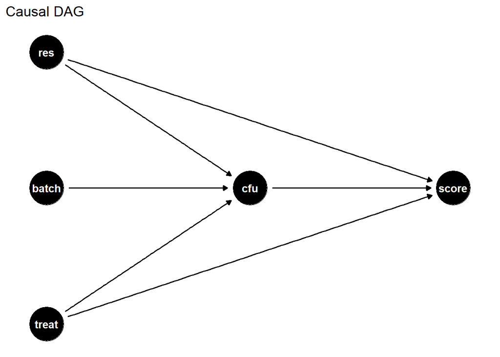

```r
dag_code <- '
dag {
  treat     [pos="0,0"]
  batch     [pos="0,1"]
  res       [pos="0,2"]
  cfu       [pos="2,1"]
  score     [pos="4,1"]
  treat         -> cfu      [label="antimicrobial_killing - expected treatment effect/mechanismx"]
  treat         -> score    [label="direct tissue effect - possible but not proved yet"]
  batch         -> cfu      [label="inoculum potency"]
  res           -> cfu      [label="immune_clearance"]
  res           -> score    [label="tissue protection "]
  cfu           -> score    [label="pathogenesis"]


}'
dag_obj <- dagitty(dag_code)
dag_ggdag <- ggdag(dag_obj)

dag_ggdag +
  theme_dag() +
  labs(
    title = "Causal DAG"
  )
```

### 1.3.1 Mediator

In this model, final bacterial load `log_CFU_mL2_s` (cfu) acts as the mediator between the treatment `treat` (treat) and the visual wound score `score2` (score). We hypothesize two distinct pathways for treatment efficacy:

> The Indirect Effect (Antimicrobial Killing): The treatment reduces bacterial density, which subsequently leads to a lower clinical score by mitigating infection-driven pathogenesis.

> The Direct Effect (Tissue Effects): The treatment may improve the wound score through mechanisms independent of bacterial load, such as moisture control or localized anti-inflammatory properties of the nanofibre dressing.

### 1.3.2 Confounders

The DAG identifies potential sources of variance that influence the healing process but were not directly measured as variables:

> Inoculum Batch (batch): Acknowledges that the initial bacterial challenge’s potency can influence the final `log_CFU_mL2_s` (cfu).

> Host Resilience (res): A theoretical latent factor representing an animal’s immunocompetence and innate healing capacity. Resilience is a common cause for both lower bacterial load (via immune clearance) and lower clinical scores (via faster re-epithelialization).

## 1.4 Implementation of causal framework

To quantify the causal pathways identified in our DAG, we implemented a *Joint Bayesian Hierarchical Model* using the brms package. Rather than running two separate regressions-—which can ignore the shared uncertainty between variables-—a joint framework allows for the simultaneous estimation of the mediator and the outcome.

### 1.4.1 Structure of the sub-models

The joint model (see Section 2.8) is composed of two components linked by the treatment effect:

> The Outcome Model (Y): We used an Adjacent-Category (ACAT) Probit model to predict the wound score (`fit1.7.0` - see Section 2.6.1.4). This specifically accounts for the ordinal nature of clinical scoring (0–3) while allowing the treatment to have a “category-specific” effect (`cs(treat)`), reflecting that the biological effort required for a “*healthy wound*” $\to$ “*inflamed wound*” transition is fundamentally different from the mechanism of an “*inflamed wound*” $\to$ “*biofilm established*” transition.

> The Mediator Model (M): We used a Gaussian model to predict the bacterial load `log_CFU_mL2_s` (`fit2.1.0`, see Section 2.7). This captures how the treatment directly impacts the microbial population.

### 1.4.2 Hierarchical design and priors

Both sub-models incorporate a nested random-effects structure `(1 | batch / cage / ID)`. This mathematically accounts for the “Host Resilience” and “Inoculum Potency” factors identified in our DAG, ensuring that individual animal variability and batch-to-batch noise do not bias our population-level expectations (`re_formula = NA`).

We applied weakly informative priors (Normal(0,1)) to the coefficients. This provides a “regularizing” effect that prevents the model from overfitting to noise while remaining open to the evidence provided by our experimental data.

### 1.4.3 Advantage of “joint model”

By fitting these models simultaneously, we can extract the proportional mediation directly from the joint posterior distribution. This allows us to decompose the total treatment effect (direct + indirect) and calculate the proportion of indirect effect (antimicrobial effect).

## 1.5 Outcome model (Y)

The true biological severity of a wound is a complex, continuous process involving inflammation, tissue damage, and bacterial burden that we cannot measure directly - we call this continuous process “*latent wound severity*”. Instead, we use the visual score (0, 1, 2, or 3) as discrete labels to track the wound’s status. Thus, the scores are specific points along the underlying *latent wound severity* scale.

To better understand how treatments and bacterial load affect wound healing, we use an Adjacent-Category (ACAT) model that connects these factors to the visual scores through the concept of *latent wound severity*.

### 1.5.1 The basic idea of the ACAT

Instead of treating the *latent wound severity* as one single underlying variable, we break it down into three separate, adjacent transitions (0 $\to$ 1, 1 $\to$ 2, 2 $\to$ 3). Each transition has its own threshold ($\tau$ - red line) that determines when the wound moves from one score to the adjacent one - see example below.

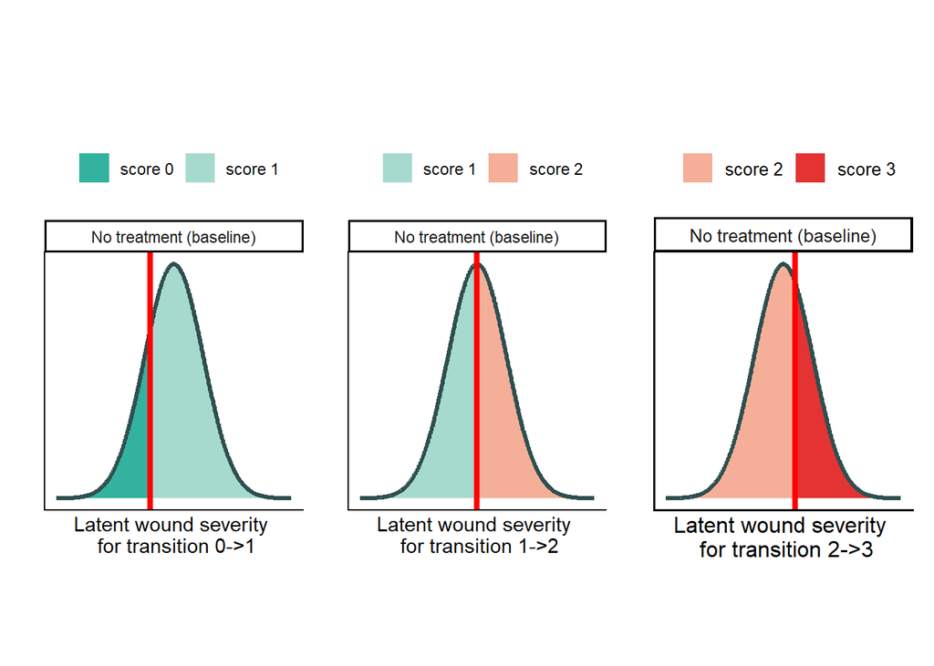

The positions of the thresholds ($\tau$ - red lines) are determined by pathophysiology of wound healing (areas under curves reflect the probability of observing given score). The ACAT allows to reflect the situation when the the biological mechanisms and energy barriers required to transition between adjacent wound states are not equivalent. For instance, try to compare these:

- transition $0 \to 1$ can be considered as transition *healthy wound* $\to$ *wound with inflammation*
- transition $1 \to 2$ can be considered as transition *wound with inflammation* $\to$ *wound with established biofilm*

In general, these transitions may not be equivalent, and thus, the positions of the thresholds ($\tau$) can differ (as shown above).

This concept can be extended to include e.g. the effects of treatments on the *latent wound severity*. In this framework, treatments shift the entire *latent wound severity* distribution left or right, thereby changing the probabilities of observing each score.

Following example illustrates the effect of the treatment on a single transition (1 $\to$ 2) by shifting the *latent wound severity* distribution left (better outcomes) relative to a fixed threshold ($\tau$ - red line).

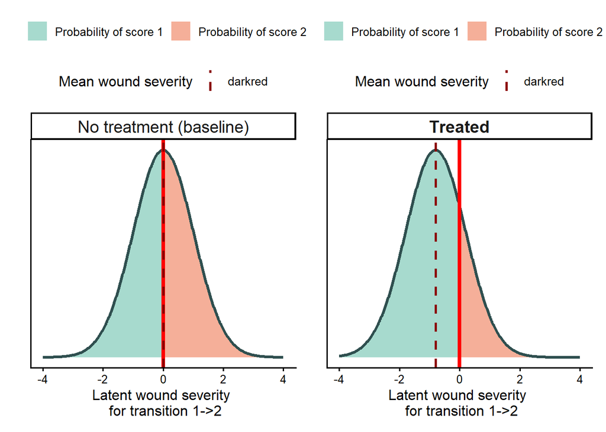

*No treatment (baseline)*: The mean severity distribution is centered at $\mathbf{0}$. The untreated group has an equal chance (50/50 probability) of being scored 1 or 2.

*Treated*: An effective treatment results in the entire severity distribution being shifted left. This negative shift results in higher probability of achieving the better outcome (score 1) compared to score 2 (see the areas under the curve).

The ACAT concept is even more important, when we consider that the tested wound treatments can provide at least two mechanism of action:

- physical barrier which regulates the environment of the wound (e.g. moisture, oxygenation, etc.)
- antibacterial activity which reduces the bacterial load in the wound.

These may influence different transitions differently, and therefore, monitoring individual transitions may be advantageous.

### 1.5.2 Formal description of the model

Before reading this section, we recommend that you first read the following publication: (Bürkner and Vuorre 2019)

We employ the Adjacent Category Model (ACM) using the probit link function $\Phi^{-1}(\cdot)$.

$$\Pr(Y_{i}=k \mid Y_{i} \in \{k, k+1 \}, \eta_{k+1,i}) =\Phi(\tau_{k+1} - \eta_{k+1,i})$$
Here:

- $Y_{i}$ - ordinal wound score for observation $i$
- $\eta_{k+1,i}$ - the linear predictor for threshold $k+1$ at observation $i$
- $\tau_{k+1}$ - the threshold parameter for adjacent categories $k$ and $k+1$
- $\Phi(\cdot)$ - the standard normal cumulative distribution function
- $k$ - reflects the wound score (0, 1, 2, 3)

The ordinal outcome $Y$ is derived from a latent continuous variables $\widetilde{Y}_{k+1}$, representing the true wound severity, which follow a standard normal distribution. Because we have 4 categories (0, 1, 2, 3), we get 3 transitions (0 $\to$ 1, 1 $\to$ 2, 2 $\to$ 3). Model includes these transitions in the form of thresholds/intercepts $\tau_{k+1}$ on the latent scale.

The model estimates the probability of getting wound score $k$ on specific scenario:

- $Y=k$: This is the event of observing the lower wound score (e.g., $k=1$).
- $Y \in \{k, k+1\}$: This is the condition. We focus only to observations that fell into one of the two adjacent categories (e.g. $k=1$ ($k$) and $k=2$ ($k+1$)).
- The probability of $Y=k$ (given the adjacent category restriction) is also conditional on the linear predictor $η$. E.g., the linear predictor reflecting the experimental treatment $j$ (factor **TREAT**) has the following form:

$$\eta_{k+1, i}= \sum_{j}^{}(\beta_{TREAT, j, k+1}\cdot TREAT_{i, j})$$
Because of the sign convention on the right site of the equation ($\tau_{k+1} - \eta_{k+1,i}$):

- $\beta_{TREAT, j, k+1} < 0$: beneficial effect, cumulative probability of lower score $k$ increases, and decreases for adjacent higher score $k+1$
- $\beta_{TREAT, j, k+1} = 0$: no treatment effect
- $\beta_{TREAT, j, k+1} > 0$: unfavorable effect, cumulative probability of lower score $k$ decreases, and increases for adjacent higher score $k+1$

For treatment **X** and specific transition $k \to k+1$ then:

- $\beta_{TREAT, X, 1}$: Effect on the 0 $\to$ 1 transition
- $\beta_{TREAT, X, 2}$: Effect on the 1 $\to$ 2 transition
- $\beta_{TREAT, X, 3}$ Effect on the 2 $\to$ 3 transition

# 2 Commented R code

## 2.1 Packages

Libraries used in this script:

**Open code**

```r
library(tidyverse)       # Collection of core R packages for data science (includes dplyr and tidyr)
library(readxl)          # Reading data directly from Excel files (.xlsx)
library(ggplot2)         # Data visualization/plotting
library(ggsci)           # Scientific journal color palettes for ggplot2
library(bayesplot)       # Visualizations for MCMC and Bayesian model checking
library(tidybayes)       # Tools for manipulating and summarizing Bayesian posterior samples
library(loo)             # Leave-One-Out cross-validation and model comparison
library(knitr)           # Dynamic document generation (e.g., R Markdown tables)
library(patchwork)       # Combining multiple ggplot2 plots into a single layout
library(brms)            # Bayesian multilevel modeling using Stan
library(ggdag)           # For DAG
library(dagitty)         # For DAG
library(marginaleffects) # Extract and plot brms results
library(patchwork)       # Compose the final plot grid
library(egg)             # Compose the final plot grid
```

## 2.2 Fuctions

To systematically check the diagnostic for our models, let’s create a function for this purpose:

**Open code**

```r
# Function to perform model evaluation
evaluate_bayesian_model <- function(fitted_model) {
  ###  Summary of a fitted model
  print(summary(fitted_model))

  ### Distribution of outcome vs. newly simulated data distribution
  print(pp_check(fitted_model, type = "bars_grouped", group = "treat", ndraws = 50))

  ### "Leave-one-out extreme value diagnostic"
  print(loo(fitted_model))
}
```

## 2.3 Load data

First, load the brms fits for smooth report rendering.

**Open code**

```r
load("C:/users/kindermann/Owncloud/4_biomedical_center/R2/1_bc/1_Projects/UOCHB_Rajman/Rmd/21082025_SAureus_Prevent_1az5/b_fit1.1.0.RData")
load("C:/users/kindermann/Owncloud/4_biomedical_center/R2/1_bc/1_Projects/UOCHB_Rajman/Rmd/21082025_SAureus_Prevent_1az5/b_fit1.2.0.RData")
load("C:/users/kindermann/Owncloud/4_biomedical_center/R2/1_bc/1_Projects/UOCHB_Rajman/Rmd/21082025_SAureus_Prevent_1az5/b_fit1.3.0.RData")
load("C:/users/kindermann/Owncloud/4_biomedical_center/R2/1_bc/1_Projects/UOCHB_Rajman/Rmd/21082025_SAureus_Prevent_1az5/b_fit1.4.0.RData")
load("C:/users/kindermann/Owncloud/4_biomedical_center/R2/1_bc/1_Projects/UOCHB_Rajman/Rmd/21082025_SAureus_Prevent_1az5/b_fit1.6.0.RData")
load("C:/users/kindermann/Owncloud/4_biomedical_center/R2/1_bc/1_Projects/UOCHB_Rajman/Rmd/21082025_SAureus_Prevent_1az5/b_fit1.7.0.RData")
load("C:/users/kindermann/Owncloud/4_biomedical_center/R2/1_bc/1_Projects/UOCHB_Rajman/Rmd/21082025_SAureus_Prevent_1az5/b_reloo1.3.0.RData")
load("C:/users/kindermann/Owncloud/4_biomedical_center/R2/1_bc/1_Projects/UOCHB_Rajman/Rmd/21082025_SAureus_Prevent_1az5/b_reloo1.4.0.RData")
load("C:/users/kindermann/Owncloud/4_biomedical_center/R2/1_bc/1_Projects/UOCHB_Rajman/Rmd/21082025_SAureus_Prevent_1az5/b_reloo1.6.0.RData")
load("C:/users/kindermann/Owncloud/4_biomedical_center/R2/1_bc/1_Projects/UOCHB_Rajman/Rmd/21082025_SAureus_Prevent_1az5/b_reloo1.7.0.RData")
load("C:/users/kindermann/Owncloud/4_biomedical_center/R2/1_bc/1_Projects/UOCHB_Rajman/Rmd/21082025_SAureus_Prevent_1az5/b_fit1.8.0.RData")
load("C:/users/kindermann/Owncloud/4_biomedical_center/R2/1_bc/1_Projects/UOCHB_Rajman/Rmd/21082025_SAureus_Prevent_1az5/b_reloo1.8.0.RData")
load("C:/users/kindermann/Owncloud/4_biomedical_center/R2/1_bc/1_Projects/UOCHB_Rajman/Rmd/21082025_SAureus_Prevent_1az5/b_fit1.7.1.RData")
load("C:/users/kindermann/Owncloud/4_biomedical_center/R2/1_bc/1_Projects/UOCHB_Rajman/Rmd/21082025_SAureus_Prevent_1az5/b_fit1.7.2.RData")
load("C:/users/kindermann/Owncloud/4_biomedical_center/R2/1_bc/1_Projects/UOCHB_Rajman/Rmd/21082025_SAureus_Prevent_1az5/b_fit1.7.3.RData")
load("C:/users/kindermann/Owncloud/4_biomedical_center/R2/1_bc/1_Projects/UOCHB_Rajman/Rmd/21082025_SAureus_Prevent_1az5/fit1.9.0.RData")
load("C:/users/kindermann/Owncloud/4_biomedical_center/R2/1_bc/1_Projects/UOCHB_Rajman/Rmd/21082025_SAureus_Prevent_1az5/fit1.10.0.RData")
load("C:/users/kindermann/Owncloud/4_biomedical_center/R2/1_bc/1_Projects/UOCHB_Rajman/Rmd/21082025_SAureus_Prevent_1az5/b_fit1.11.0.RData")
load("C:/users/kindermann/Owncloud/4_biomedical_center/R2/1_bc/1_Projects/UOCHB_Rajman/Rmd/21082025_SAureus_Prevent_1az5/b_fit2.1.0.RData")
load("C:/users/kindermann/Owncloud/4_biomedical_center/R2/1_bc/1_Projects/UOCHB_Rajman/Rmd/21082025_SAureus_Prevent_1az5/fit_joint.RData")
```

Let’s load measured data, check the structure and assign the correct data type to each variable:

**Open code**

```r
file_name <- "LPPO_CFU.xlsx"
sheet_name <-"CFU"
sheet_range <- "A1:N95"
file_path <- "C:/users/kindermann/Owncloud/4_biomedical_center/R2/1_bc/1_Projects/UOCHB_Rajman/data/21082025_SAureus_Prevent_1az5/LPPO_CFU2.xlsx"
data1.1 <- read_excel(file_path, sheet = sheet_name, range = sheet_range)

data1.1 <-
  data1.1 |>
  mutate(score = as.ordered(score),
         treat = as.factor(treat),
         cage = as.factor(cage),
         batch = as.factor(batch),
         ID = as.factor(ID),
         site = as.factor(site),
         CFU_mL = as.numeric(CFU_mL))

knitr::kable(data1.1)
```

| ID | site | cage | score | treat | test_ID | type | batch | sample_processing | quantification | N_colonies | TDF | plated_volume_mL | CFU_mL |
| --- | --- | --- | --- | --- | --- | --- | --- | --- | --- | --- | --- | --- | --- |
| LPPO_1 | L | 1 | 0 | B | 16 | SA | 1 | 27.6.2025 | 30.6.2025 | 13 | 1e+00 | 0.1 | 2.6130e+04 |
| LPPO_1 | R | 1 | 0 | A | 16 | SA | 1 | 27.6.2025 | 30.6.2025 | 170 | 1e+00 | 0.1 | 3.4170e+05 |
| LPPO_2 | L | 1 | 0 | H | 16 | SA | 1 | 27.6.2025 | 30.6.2025 | 30 | 1e+01 | 0.1 | 6.0300e+05 |
| LPPO_2 | R | 1 | 3 | E | 16 | SA | 1 | 27.6.2025 | 30.6.2025 | 200 | 1e+03 | 0.1 | 4.0200e+08 |
| LPPO_3 | L | 1 | 0 | G | 16 | SA | 1 | 27.6.2025 | 30.6.2025 | 8 | 1e+00 | 0.1 | 1.6080e+04 |
| LPPO_3 | R | 1 | 1 | E | 16 | SA | 1 | 27.6.2025 | 30.6.2025 | 0 | 1e+00 | 0.1 | 0.0000e+00 |
| LPPO_4 | L | 1 | 2 | Ag | 16 | SA | 1 | 27.6.2025 | 30.6.2025 | 43 | 1e+03 | 0.1 | 8.6430e+07 |
| LPPO_4 | R | 1 | 3 | Cosmopor | 16 | SA | 1 | 27.6.2025 | 30.6.2025 | 30 | 1e+04 | 0.1 | 6.0300e+08 |
| LPPO_5 | L | 1 | 0 | B | 16 | SA | 1 | 27.6.2025 | 30.6.2025 | 0 | 1e+00 | 0.1 | 0.0000e+00 |
| LPPO_5 | R | 1 | 4 | A | 16 | SA | 1 | 27.6.2025 | 30.6.2025 | 50 | 1e+05 | 0.1 | 1.0050e+10 |
| LPPO_6 | L | 2 | 2 | H | 16 | SA | 1 | 27.6.2025 | 30.6.2025 | 130 | 1e+02 | 0.1 | 2.6130e+07 |
| LPPO_6 | R | 2 | 4 | E | 16 | SA | 1 | 27.6.2025 | 30.6.2025 | 36 | 1e+04 | 0.1 | 7.2360e+08 |
| LPPO_7 | L | 2 | 3 | G | 16 | SA | 1 | 27.6.2025 | 30.6.2025 | 33 | 1e+03 | 0.1 | 6.6330e+07 |
| LPPO_7 | R | 2 | 4 | E | 16 | SA | 1 | 27.6.2025 | 30.6.2025 | 40 | 1e+04 | 0.1 | 8.0400e+08 |
| LPPO_8 | L | 2 | 3 | Ag | 16 | SA | 1 | 27.6.2025 | 30.6.2025 | 90 | 1e+03 | 0.1 | 1.8090e+08 |
| LPPO_8 | R | 2 | 3 | Cosmopor | 16 | SA | 1 | 27.6.2025 | 30.6.2025 | 60 | 1e+03 | 0.1 | 1.2060e+08 |
| LPPO_9 | L | 2 | 0 | B | 16 | SA | 1 | 27.6.2025 | 30.6.2025 | 32 | 1e+00 | 0.1 | 6.4320e+04 |
| LPPO_9 | R | 2 | 4 | A | 16 | SA | 1 | 27.6.2025 | 30.6.2025 | 36 | 1e+05 | 0.1 | 7.2360e+09 |
| LPPO_10 | L | 3 | NA | Ag | 17 | SA | 2 | NA | NA | NA | NA | NA | NA |
| LPPO_10 | R | 3 | NA | Cosmopor | 17 | SA | 2 | NA | NA | NA | NA | NA | NA |
| LPPO_11 | L | 3 | 3 | G | 17 | SA | 2 | 4.7.2025 | 7.7.2025 | 96 | 1e+03 | 0.1 | 1.9296e+08 |
| LPPO_11 | R | 3 | 4 | E | 17 | SA | 2 | 4.7.2025 | 7.7.2025 | 51 | 1e+04 | 0.1 | 1.0251e+09 |
| LPPO_12 | L | 3 | 0 | H | 17 | SA | 2 | 4.7.2025 | 7.7.2025 | 38 | 1e+00 | 0.1 | 7.6380e+04 |
| LPPO_12 | R | 3 | 4 | E | 17 | SA | 2 | 4.7.2025 | 7.7.2025 | 37 | 1e+04 | 0.1 | 7.4370e+08 |
| LPPO_13 | L | 3 | 1 | H | 17 | SA | 2 | 4.7.2025 | 7.7.2025 | 170 | 1e+02 | 0.1 | 3.4170e+07 |
| LPPO_13 | R | 3 | 4 | E | 17 | SA | 2 | 4.7.2025 | 7.7.2025 | 153 | 1e+04 | 0.1 | 3.0753e+09 |
| LPPO_14 | L | 4 | 3 | G | 17 | SA | 2 | 4.7.2025 | 7.7.2025 | 270 | 1e+02 | 0.1 | 5.4270e+07 |
| LPPO_14 | R | 4 | 4 | E | 17 | SA | 2 | 4.7.2025 | 7.7.2025 | 110 | 1e+03 | 0.1 | 2.2110e+08 |
| LPPO_15 | L | 4 | 0 | B | 17 | SA | 2 | 4.7.2025 | 7.7.2025 | 290 | 1e+00 | 0.1 | 5.8290e+05 |
| LPPO_15 | R | 4 | 4 | A | 17 | SA | 2 | 4.7.2025 | 7.7.2025 | 41 | 1e+04 | 0.1 | 8.2410e+08 |

[output cut: 64 more lines]

## 2.4 Data exploration

Check the basic data visualization and total counts in our data set:

**Open code**

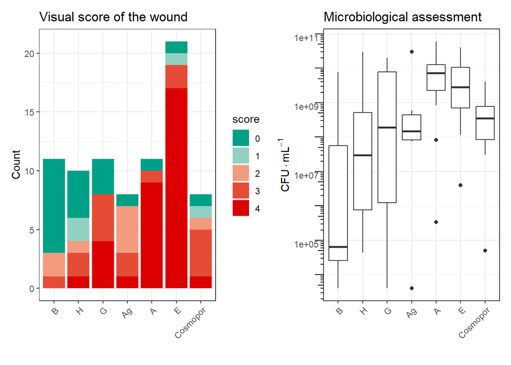

```r
# Score visualization:
plot_data1 <-
  data1.1 |>
  mutate(treat = factor(treat, levels = c("B", "H", "G", "Ag", "A", "E", "Cosmopor"))) |>
  filter(score != "NA") |>
  group_by(treat, score) |>
  summarize(count = n())

plot_data1 <-
  plot_data1 |>
  filter(!is.na(treat))

p1 <-
plot_data1 |>
ggplot(aes(x = treat, y = count, fill = factor(score))) +
  geom_bar(stat = "identity") +
  labs(title = "Visual score of the wound",
       x = "",
       y = "Count",
       fill = "score") +
  theme_bw() +
  scale_fill_manual(values = c(mypal[3], mypal[7], mypal[5], mypal[1], mypal[8])) +
  theme(axis.text.x = element_text(angle = 45, vjust = 1, hjust=1))


# CFU_mL visualization:
plot_data2 <-
  data1.1 |>
  mutate(treat = factor(treat, levels = c("B", "H", "G", "Ag", "A", "E", "Cosmopor"))) |>
  filter(!is.na(CFU_mL) & CFU_mL != 0)

plot_data2 <-
  plot_data2 |>
  filter(!is.na(treat))

p2 <-
plot_data2 |>
ggplot(aes(x = treat, y = CFU_mL)) +
  geom_boxplot() +
  labs(
    title = "Microbiological assessment",
    x = "",
    y = bquote(CFU%.%mL^-1),
  ) +
  scale_y_log10() +
  theme_bw() +
  annotation_logticks(sides = "l", outside = TRUE) +
  coord_cartesian(clip = "off") +
  theme(axis.text.x = element_text(angle = 45, vjust = 1, hjust=1),
        axis.text.y = element_text(angle = 0, vjust = 1, hjust=1))

# Plot both graphs
p1 | p2
```

**Open code**

```r
# Total counts in our data
total_counts <-
  data1.1 |>
  mutate(treat = factor(treat, levels = c("B", "H", "G", "Ag", "A", "E", "Cosmopor"))) |>
  filter(score != "NA") |>
  group_by(score) |>
  summarize(count = n())

knitr::kable(total_counts)
```

| score | count |
| --- | --- |
| 0 | 19 |
| 1 | 4 |
| 2 | 8 |
| 3 | 16 |
| 4 | 33 |

At first glance, we can see the correlation between the `score` and `CFU_mL` (score 0 is related to low CFU values; score 4 is related with high CFU values)

We can also see that score 1 was observed only 4 times. This may affect the reliability of our model estimates (specifically transitions 0 $\to$ 1 and 1 $\to$ 2). Later (see section “Data wrangling”), we aggregate score 1 and score 2 into a single category (see the new score definition above).

To visualize the relationship between `score` and `CFU_mL`, we create a scatter plot with jitter of our visual scores grouped by log$_{10}$(`CFU_mL`):

**Open code**

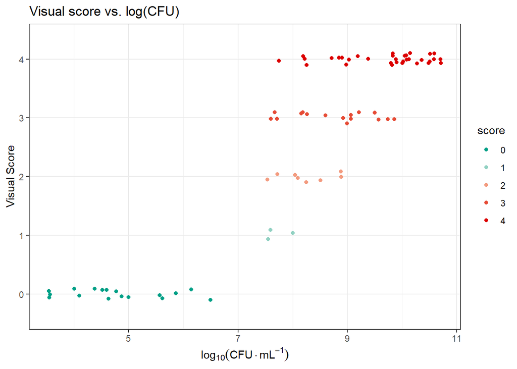

```r
plot_data3 <-
  data1.1 |>
  filter(!is.na(score) & score != "NA") |>
  filter(!is.na(CFU_mL) & CFU_mL != 0) |>
  mutate(log_CFU_mL = log10(CFU_mL))

ggplot(plot_data3, aes(x = log_CFU_mL, y = score, group = score, color = score)) +
  geom_jitter(width = 0.2, height = 0.1, alpha = 1) +
  labs(
    title = "Visual score vs. log(CFU)",
    x = bquote(log[10](CFU%.%mL^-1)),
    y = "Visual Score"
  ) +
  theme_bw() +
  scale_color_manual(values = c(mypal[3], mypal[7], mypal[5], mypal[1], mypal[8]))
```

Visual score 0 is clearly separated and spans a wide range of log$_{10}$(`CFU_mL`). Scores 1, 2, 3, and 4 are overlapping but show a trend.

We can also visualize the grouped data by treatment:

**Open code**

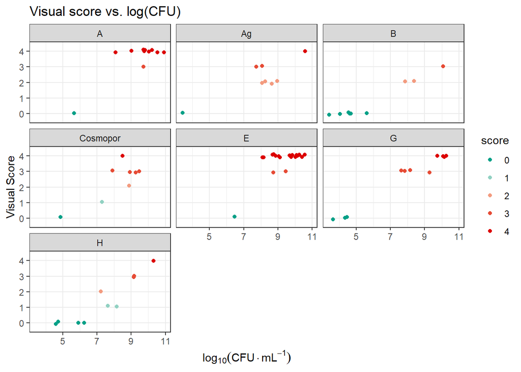

```r
plot_data3 <-
  data1.1 |>
  filter(!is.na(score) & score != "NA") |>
  filter(!is.na(CFU_mL) & CFU_mL != 0) |>
  mutate(log_CFU_mL = log10(CFU_mL))

ggplot(plot_data3, aes(x = log_CFU_mL, y = score, group = score, color = score)) +
  geom_jitter(width = 0.2, height = 0.1, alpha = 1) +
  labs(
    title = "Visual score vs. log(CFU)",
    x = bquote(log[10](CFU%.%mL^-1)),
    y = "Visual Score"
  ) +
  theme_bw() +
  facet_wrap(~treat) +
  scale_color_manual(values = c(mypal[3], mypal[7], mypal[5], mypal[1], mypal[8]))
```

## 2.5 Data wrangling

First, let’s aggregate score 1 and 2 into a single category (as discussed above):

**Open code**

```r
data1.2 <-
  data1.1 |>
  mutate(score2 = case_when(score == "2" ~ "1",
                            .default = score)) |>
  mutate(score2 = case_when(score2 == "3" ~ "2",
                            score2 == "4" ~ "3",
                            .default = score2)) |>
  relocate(score2, .after = score) |>
  mutate(score2 = as.ordered(score2)) |>
  drop_na(CFU_mL) |>
  mutate(CFU_mL2 = case_when(CFU_mL == 0 ~ 1005,
                             .default = CFU_mL)) |>
  mutate(log_CFU_mL2 = log10(CFU_mL2))
```

Check for total counts in our data set after aggregation:

**Open code**

```r
total_counts <-
  data1.2 |>
  mutate(treat = factor(treat, levels = c("B", "H", "G", "Ag", "A", "E", "Cosmopor"))) |>
  filter(score2 != "NA") |>
  group_by(score2) |>
  summarize(count = n())

knitr::kable(total_counts)
```

| score2 | count |
| --- | --- |
| 0 | 19 |
| 1 | 12 |
| 2 | 16 |
| 3 | 33 |

Due to multiplicative nature of bacterial effects rather than additive ones, we will logarithmize the `CFU_mL` variable. However, since some `CFU_mL` values are exactly zero, we will first replace these zeros with a small value (1005 CFU $\cdot$ mL$^{-1}$), which is half of the minimum detectable limit) before applying the logarithm transformation (see section “Data description”). We also standardize the log-transformed variable to have a mean of 0 and a standard deviation of 1 due to better interpretation of the model coefficients:

**Open code**

```r
# Logarithmization of the CFU_mL variable
data1.2 <-
  data1.2 |>
  mutate(CFU_mL2 = case_when(CFU_mL == 0 ~ 1005,
                             .default = CFU_mL)) |>
  mutate(log_CFU_mL2 = log10(CFU_mL2))

# Standardization of the log_CFU_mL2
log_CFU_mL2_mean <- mean(data1.2$log_CFU_mL2)
log_CFU_mL2_sd <- sd(data1.2$log_CFU_mL2)

data1.2 <-
  data1.2 |>
  mutate(log_CFU_mL2_s = (log_CFU_mL2 - log_CFU_mL2_mean) / log_CFU_mL2_sd)
```

Finally, make sure our data has the correct structure and data type:

**Open code**

```r
data1.2 <-
  data1.2 |>
  # remove all NAs from score
  filter(score2 != "NA" & !is.na(score2)) |>
  # IMPORTANT - specify all available levels (otherwise, "NA" can occur as a separate level)
  mutate(score2 = factor(score2, levels = c("0", "1", "2", "3"))) |>
  # set the treat variable as a factor
  mutate(treat = factor(treat, levels = c("B", "H", "Ag", "G", "Cosmopor", "E", "A"))) |>
  # set the "Cosmopor" as reference level
  mutate(treat = relevel(treat, ref = "Cosmopor")) |>
  mutate(score2 = as.ordered(score2),
         treat = as.factor(treat),
         cage = as.factor(cage),
         batch = as.factor(batch),
         ID = as.factor(ID),
         site = as.factor(site),
         log_CFU_mL2 = as.numeric(log_CFU_mL2),
         log_CFU_mL2_s = as.numeric(log_CFU_mL2_s))

#save(data1.2, file = "data1.2.RData")
```

## 2.6 Formal analysis

### 2.6.1 Outcome model (Y)

#### 2.6.1.1 Fit1.1.0

$\eta_{k+1, i} = 0$

Since the ACM uses the probit link, it assumes the underlying latent severity ($\widetilde{Y}_{k+1}$) follows a standard normal distribution, normal(0, 1). $\tau_{k+1}$ represents the point on this latent scale. Then the probability of the wound with lower score over the adjacent higher score is $\Phi(\tau_{k+1})$.

Weakly informative normal(0, 2) on the Intercepts ensures the thresholds are near zero on the latent scales $\widetilde{Y}_{k+1}$. In other words, we expect that, before observing any data, the probability of scoring $k$ is equal to the probability of scoring $k+1$ for every adjacent pair.

**Open code**

```r
set.seed = 225

bm1.1.0 <- bf(score2 ~ 1)

fit1.1.0  <- brm(bm1.1.0,
             data = data1.2,
             family = acat("probit"),
             warmup = 1000,
             iter = 4000,
             chains = 4,
             cores = 10,
             control = list(adapt_delta = 0.99, max_treedepth = 15),
             #save_all_pars = TRUE,
             sample_prior = TRUE,
             prior = c(prior(normal(0, 2), class = Intercept)))

fit1.1.0 <- add_criterion(fit1.1.0, "loo")

save(fit1.1.0, file = "b_fit1.1.0.RData")
```

Fit1.1.0:  
Model summary:

**Open code**

```r
summary(fit1.1.0 )
```

```
 Family: acat
  Links: mu = probit
Formula: score2 ~ 1
   Data: data1.2 (Number of observations: 80)
  Draws: 4 chains, each with iter = 4000; warmup = 1000; thin = 1;
         total post-warmup draws = 12000

Regression Coefficients:
             Estimate Est.Error l-95% CI u-95% CI Rhat Bulk_ESS Tail_ESS
Intercept[1]     0.27      0.22    -0.17     0.71 1.00     5041     5771
Intercept[2]    -0.17      0.24    -0.62     0.30 1.00     4146     5371
Intercept[3]    -0.46      0.19    -0.82    -0.10 1.00     4734     4880

Further Distributional Parameters:
     Estimate Est.Error l-95% CI u-95% CI Rhat Bulk_ESS Tail_ESS
disc     1.00      0.00     1.00     1.00   NA       NA       NA

Draws were sampled using sampling(NUTS). For each parameter, Bulk_ESS
and Tail_ESS are effective sample size measures, and Rhat is the potential
scale reduction factor on split chains (at convergence, Rhat = 1).
```

Note: Estimated coefficients $\color{pink}{\text{Intercept[1]}}$, $\color{pink}{\text{Intercept[2]}}$ etc., correspond to $\tau_{1}$, $\tau_{2}$ etc. (before including any treatment or microbial load effects).

#### 2.6.1.2 Fit1.2.0

$\eta_{k+1, i}= \sum_{j}^{}(\beta_{TREAT, j, k+1}\cdot TREAT_{i, j})$

Model estimates the effect of each treatment group on the score, relative to the control group (**Cosmopor**).

Weakly informative normal(0, 2) on the treatment coefficients. This allows for reasonably large differences between treatment groups. In other words, we expect no treatment effect before observing any data.

**Open code**

```r
set.seed = 225

fit1.2.0 <- update(fit1.1.0,
                   newdata = data1.2,
                   formula = bf(score2 ~ 1 + cs(treat)),
                   prior = c(prior(normal(0, 2), class = Intercept),
                             prior(normal(0, 2), class = b)))

fit1.2.0 <- add_criterion(fit1.2.0, "loo")

save(fit1.2.0, file = "b_fit1.2.0.RData")
```

Fit1.2.0:  
Model summary:  
Posterior predictive check - bars grouped by treatment:  
Leave-one-out cross-validation information criterion:

**Open code**

```
 Family: acat
  Links: mu = probit
Formula: score2 ~ cs(treat)
   Data: data1.2 (Number of observations: 80)
  Draws: 4 chains, each with iter = 4000; warmup = 1000; thin = 1;
         total post-warmup draws = 12000

Regression Coefficients:
             Estimate Est.Error l-95% CI u-95% CI Rhat Bulk_ESS Tail_ESS
Intercept[1]    -0.13      0.52    -1.20     0.87 1.00     4645     6509
Intercept[2]    -0.43      0.45    -1.29     0.44 1.00     5881     8448
Intercept[3]     0.52      0.49    -0.40     1.49 1.00     5164     7008
treatB[1]       -1.01      0.66    -2.31     0.24 1.00     5923     8160
treatB[2]       -0.97      0.81    -2.62     0.59 1.00     9276     8813
treatB[3]       -1.29      1.45    -4.41     1.22 1.00    12011     8256
treatH[1]       -0.33      0.68    -1.67     0.99 1.00     5616     6977
treatH[2]       -0.67      0.66    -1.98     0.62 1.00     7814     8786
treatH[3]       -0.01      0.82    -1.66     1.53 1.00     8593     9534
treatAg[1]       0.69      0.79    -0.84     2.27 1.00     7270     7839
treatAg[2]      -0.81      0.65    -2.09     0.44 1.00     8100     8904
treatAg[3]      -0.02      0.82    -1.64     1.53 1.00     8581     8868
treatG[1]       -1.45      0.95    -3.43     0.30 1.00     6717     7179
treatG[2]        1.09      0.88    -0.52     2.94 1.00     7201     7173
treatG[3]        0.54      0.63    -0.67     1.78 1.00     6857     8366
treatE[1]       -0.05      0.90    -1.79     1.73 1.00     8404     8421
treatE[2]        0.12      0.76    -1.37     1.59 1.00     7443     8177
treatE[3]        1.77      0.60     0.62     2.96 1.00     6180     7463
treatA[1]       -0.94      1.10    -3.15     1.16 1.00     8268     7457
treatA[2]        0.67      1.02    -1.28     2.76 1.00     8135     7208
treatA[3]        1.84      0.68     0.53     3.20 1.00     7409     8565

Further Distributional Parameters:
     Estimate Est.Error l-95% CI u-95% CI Rhat Bulk_ESS Tail_ESS
disc     1.00      0.00     1.00     1.00   NA       NA       NA

Draws were sampled using sampling(NUTS). For each parameter, Bulk_ESS
and Tail_ESS are effective sample size measures, and Rhat is the potential
scale reduction factor on split chains (at convergence, Rhat = 1).
```

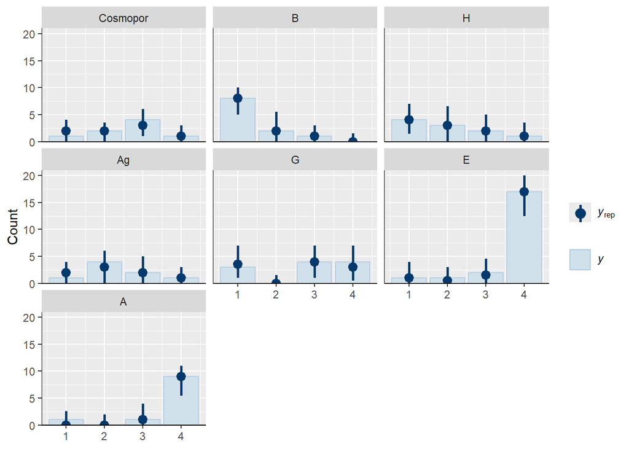

```
Computed from 12000 by 80 log-likelihood matrix.

         Estimate   SE
elpd_loo    -96.5  9.8
p_loo        21.5  3.5
looic       193.0 19.6
------
MCSE of elpd_loo is NA.
MCSE and ESS estimates assume MCMC draws (r_eff in [0.4, 1.5]).

Pareto k diagnostic values:
                         Count Pct.    Min. ESS
(-Inf, 0.7]   (good)     75    93.8%   544
   (0.7, 1]   (bad)       5     6.2%   <NA>
   (1, Inf)   (very bad)  0     0.0%   <NA>
See help('pareto-k-diagnostic') for details.
```

```r
evaluate_bayesian_model(fit1.2.0)
```

Interpretation of $\beta_{TREAT, j, k+1}$:

E.g. the $\color{pink}{\text{treatA[3]}}$, resp. $\beta_{TREAT, A, 3}$: **A** increases the underlying latent Z-score for the 2 $\to$ 3 transition by 1.84 units, relative to **Cosmopor** ($\beta_{TREAT, A, 3} > 0$). This means that treatment **A** is less effective at preventing progression from score 2 to score 3, compared to **Cosmopor**.

#### 2.6.1.3 Fit1.3.0

$\eta_{k+1, i}= \sum_{j}^{}(\beta_{TREAT, j, k+1}\cdot TREAT_{i, j}) + \beta_{logcfu}\cdot logcfu_{i}$

Model tests the independent effect of the standardized microbial load (continuous covariate) on the score, in addition to the treatment factor.

Importantly, this model expects proportionality for standardized `log_CFU_mL2_s` covariate. It estimates a single coefficient $\color{pink}{\text{log\_CFU\_mL2\_s}}$ ($\beta_{logCFU}$). This coefficient represents the increase in severity for a 1-unit increase in `log_CFU_mL2_s`, and this effect is assumed to be the same (proportional) across all transitions (0 $\to$ 1, 1 $\to$ 2 etc.).

The prior for ($\beta_{logcfu}$) is centered around zero - no effect prior to observing the data.

**Open code**

```r
set.seed = 225

fit1.3.0 <- update(fit1.2.0,
                   newdata = data1.2,
                   formula = bf(score2 ~ 1 + cs(treat) + log_CFU_mL2_s),
                   prior = c(prior(normal(0, 2), class = Intercept),
                             prior(normal(0, 2), class = b, coef = "treatA"),
                             prior(normal(0, 2), class = b, coef = "treatAg"),
                             prior(normal(0, 2), class = b, coef = "treatB"),
                             prior(normal(0, 2), class = b, coef = "treatE"),
                             prior(normal(0, 2), class = b, coef = "treatG"),
                             prior(normal(0, 2), class = b, coef = "treatH"),
                             prior(normal(0, 2), class = b, coef = "log_CFU_mL2_s")))

fit1.3.0 <- add_criterion(fit1.3.0, "loo")

save(fit1.3.0, file = "b_fit1.3.0.RData")
```

Fit1.3.0:  
Model summary:  
Posterior predictive check - bars grouped by treatment:

**Open code**

```
 Family: acat
  Links: mu = probit
Formula: score2 ~ cs(treat) + log_CFU_mL2_s
   Data: data1.2 (Number of observations: 80)
  Draws: 4 chains, each with iter = 4000; warmup = 1000; thin = 1;
         total post-warmup draws = 12000

Regression Coefficients:
              Estimate Est.Error l-95% CI u-95% CI Rhat Bulk_ESS Tail_ESS
Intercept[1]     -1.39      0.73    -2.83     0.00 1.00     4980     7870
Intercept[2]     -0.11      0.49    -1.09     0.82 1.00     5534     6775
Intercept[3]      1.45      0.51     0.49     2.47 1.00     5299     6850
log_CFU_mL2_s     2.09      0.37     1.41     2.85 1.00     7962     8201
treatB[1]        -0.36      0.97    -2.30     1.49 1.00     7117     8583
treatB[2]        -1.14      0.99    -3.15     0.71 1.00     8381     7908
treatB[3]        -1.53      1.40    -4.53     0.96 1.00     9648     7684
treatH[1]        -0.28      0.88    -2.00     1.46 1.00     6310     8350
treatH[2]        -0.59      0.78    -2.13     0.91 1.00     7765     8676
treatH[3]        -0.38      0.92    -2.19     1.38 1.00     9318     9329
treatAg[1]        0.78      1.17    -1.42     3.12 1.00     8157     8794
treatAg[2]       -0.81      0.69    -2.19     0.51 1.00     6773     8439
treatAg[3]       -0.28      0.93    -2.17     1.45 1.00     9832     8743
treatG[1]        -0.49      1.31    -3.15     1.93 1.00     9407     9017
treatG[2]         2.03      1.20    -0.10     4.61 1.00    10301     8789
treatG[3]         0.32      0.70    -1.05     1.71 1.00     7475     8544
treatE[1]         1.34      0.97    -0.56     3.24 1.00     6487     7850
treatE[2]         0.59      0.93    -1.17     2.48 1.00     8832     8758
treatE[3]         1.63      0.62     0.46     2.89 1.00     6560     7914
treatA[1]        -0.79      1.32    -3.48     1.73 1.00     8858     8211
treatA[2]         1.29      1.27    -1.02     3.93 1.00    10313     8650
treatA[3]         1.31      0.71    -0.06     2.73 1.00     7493     8208

Further Distributional Parameters:
     Estimate Est.Error l-95% CI u-95% CI Rhat Bulk_ESS Tail_ESS
disc     1.00      0.00     1.00     1.00   NA       NA       NA

Draws were sampled using sampling(NUTS). For each parameter, Bulk_ESS
and Tail_ESS are effective sample size measures, and Rhat is the potential
scale reduction factor on split chains (at convergence, Rhat = 1).
```

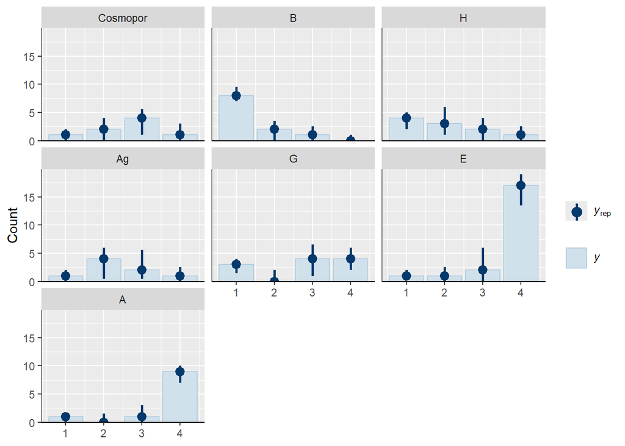

```
Computed from 12000 by 80 log-likelihood matrix.

         Estimate   SE
elpd_loo    -58.3 11.0
p_loo        20.5  6.0
looic       116.6 22.0
------
MCSE of elpd_loo is NA.
MCSE and ESS estimates assume MCMC draws (r_eff in [0.4, 1.6]).

Pareto k diagnostic values:
                         Count Pct.    Min. ESS
(-Inf, 0.7]   (good)     76    95.0%   956
   (0.7, 1]   (bad)       2     2.5%   <NA>
   (1, Inf)   (very bad)  2     2.5%   <NA>
See help('pareto-k-diagnostic') for details.
```

```r
evaluate_bayesian_model(fit1.3.0)
```

Comparison of `fit1.1.0`, `fit1.2.0`, and `fit1.3.0` using LOOIC:

**Open code**

```r
loo(fit1.1.0, fit1.2.0, fit1.3.0)
```

```
Output of model 'fit1.1.0':

Computed from 12000 by 80 log-likelihood matrix.

         Estimate  SE
elpd_loo   -108.1 3.6
p_loo         3.0 0.2
looic       216.1 7.1
------
MCSE of elpd_loo is 0.0.
MCSE and ESS estimates assume MCMC draws (r_eff in [0.4, 0.8]).

All Pareto k estimates are good (k < 0.7).
See help('pareto-k-diagnostic') for details.

Output of model 'fit1.2.0':

Computed from 12000 by 80 log-likelihood matrix.

         Estimate   SE
elpd_loo    -96.5  9.8
p_loo        21.5  3.5
looic       193.0 19.6
------
MCSE of elpd_loo is NA.
MCSE and ESS estimates assume MCMC draws (r_eff in [0.4, 1.5]).

Pareto k diagnostic values:
                         Count Pct.    Min. ESS
(-Inf, 0.7]   (good)     75    93.8%   544
   (0.7, 1]   (bad)       5     6.2%   <NA>
   (1, Inf)   (very bad)  0     0.0%   <NA>
See help('pareto-k-diagnostic') for details.

Output of model 'fit1.3.0':

Computed from 12000 by 80 log-likelihood matrix.

         Estimate   SE
elpd_loo    -58.3 11.0
p_loo        20.5  6.0
looic       116.6 22.0
------
MCSE of elpd_loo is NA.
MCSE and ESS estimates assume MCMC draws (r_eff in [0.4, 1.6]).

Pareto k diagnostic values:
                         Count Pct.    Min. ESS
(-Inf, 0.7]   (good)     76    95.0%   956
   (0.7, 1]   (bad)       2     2.5%   <NA>
   (1, Inf)   (very bad)  2     2.5%   <NA>
See help('pareto-k-diagnostic') for details.

Model comparisons:
         elpd_diff se_diff
fit1.3.0   0.0       0.0
fit1.2.0 -38.2       8.8
fit1.1.0 -49.8      10.4
```

The coefficient $\color{pink}{\text{log\_CFU\_mL2\_s}}$ is positive (higher bacterial load is associated with a worse outcome).

#### 2.6.1.4 Fit1.4.0 / Fit1.6.0 / Fit1.7.0

This set of (random intercept) models correct for data grouping (nested experimental design).

- `fit1.4.0` - corrects for the `batch` grouping
- `fit1.6.0` - corrects for the `batch` + `cage` grouping
- `fit1.7.0` - corrects for the `batch` + `cage` + `ID` grouping

Formal notation for `fit1.7.0`:

$\eta_{k+1, i}= \sum_{j}^{}(\beta_{TREAT, j, k+1}\cdot TREAT_{i, j}) + \beta_{logcfU}\cdot logcfu_{i} + u_{BATCH[m[i]]} + u_{CAGE[m[i], n[i]]} + u_{ID[m[i], n[i], p[i]]}$, where

$\mathrm{u}_{BATCH}^{(m)} \sim N(0, \sigma^{2}_{BATCH})$  
$\mathrm{u}_{CAGE(BATCH)}^{(m, n)} \sim N(0, \sigma^{2}_{CAGE(BATCH)})$  
$\mathrm{u}_{ID(CAGE(BATCH))}^{(m, n, p)} \sim N(0, \sigma^{2}_{ID(CAGE(BATCH))})$

**Open code**

```r
set.seed = 225

fit1.4.0 <- update(fit1.3.0,
                   newdata = data1.2,
                   formula = bf(score2 ~ 1 + cs(treat) + log_CFU_mL2_s + (1 | batch)))

fit1.6.0 <- update(fit1.4.0,
                   newdata = data1.2,
                   formula = bf(score2 ~ 1 + cs(treat) + log_CFU_mL2_s + (1 | batch / cage)))


fit1.7.0 <- update(fit1.6.0,
                   newdata = data1.2,
                   formula = bf(score2 ~ 1 + cs(treat) + log_CFU_mL2_s + (1 | batch / cage / ID)))

fit1.4.0 <- add_criterion(fit1.4.0, "loo")
fit1.6.0 <- add_criterion(fit1.6.0, "loo")
fit1.7.0 <- add_criterion(fit1.7.0, "loo")

save(fit1.4.0, file = "b_fit1.4.0.RData")
save(fit1.6.0, file = "b_fit1.6.0.RData")
save(fit1.7.0, file = "b_fit1.7.0.RData")
```

`fit1.4.0`:  
Model summary:  
Posterior predictive check - bars grouped by treatment:  
Leave-one-out cross-validation information criterion:

**Open code**

```
 Family: acat
  Links: mu = probit
Formula: score2 ~ cs(treat) + log_CFU_mL2_s + (1 | batch)
   Data: data1.2 (Number of observations: 80)
  Draws: 4 chains, each with iter = 4000; warmup = 1000; thin = 1;
         total post-warmup draws = 12000

Multilevel Hyperparameters:
~batch (Number of levels: 5)
              Estimate Est.Error l-95% CI u-95% CI Rhat Bulk_ESS Tail_ESS
sd(Intercept)     1.12      0.58     0.36     2.59 1.00     4574     5526

Regression Coefficients:
              Estimate Est.Error l-95% CI u-95% CI Rhat Bulk_ESS Tail_ESS
Intercept[1]     -1.81      0.85    -3.52    -0.20 1.00     6806     8567
Intercept[2]     -0.21      0.71    -1.65     1.18 1.00     5869     7269
Intercept[3]      1.95      0.73     0.58     3.48 1.00     5462     6903
log_CFU_mL2_s     2.54      0.47     1.69     3.49 1.00    10073     8665
treatB[1]        -0.83      1.06    -2.89     1.20 1.00    11948     9534
treatB[2]        -1.94      1.06    -4.05     0.08 1.00    13173     9407
treatB[3]        -1.92      1.35    -4.80     0.51 1.00    15280     8207
treatH[1]        -0.49      0.96    -2.40     1.35 1.00    10721     9203
treatH[2]        -0.97      0.84    -2.63     0.64 1.00    10131     9068
treatH[3]        -0.70      1.02    -2.73     1.25 1.00    14190     8543
treatAg[1]        0.86      1.36    -1.61     3.67 1.00    14067     8559
treatAg[2]       -1.07      0.76    -2.61     0.38 1.00    10123     9519
treatAg[3]       -0.43      1.08    -2.59     1.61 1.00    15489     9501
treatG[1]        -0.47      1.47    -3.44     2.23 1.00    13822     8561
treatG[2]         1.76      1.27    -0.44     4.50 1.00    11728     8270
treatG[3]         0.40      0.75    -1.08     1.87 1.00    10536     9159
treatE[1]         1.84      1.01    -0.10     3.82 1.00    11790     9226
treatE[2]         0.96      1.08    -1.07     3.16 1.00    14744     9583
treatE[3]         1.86      0.68     0.59     3.22 1.00     9034     8734
treatA[1]        -1.05      1.40    -3.86     1.60 1.00    13745     9200
treatA[2]         0.93      1.36    -1.59     3.73 1.00    13388     9186
treatA[3]         1.66      0.79     0.18     3.30 1.00    10397     9240

Further Distributional Parameters:
     Estimate Est.Error l-95% CI u-95% CI Rhat Bulk_ESS Tail_ESS
disc     1.00      0.00     1.00     1.00   NA       NA       NA

Draws were sampled using sampling(NUTS). For each parameter, Bulk_ESS
and Tail_ESS are effective sample size measures, and Rhat is the potential
scale reduction factor on split chains (at convergence, Rhat = 1).
```

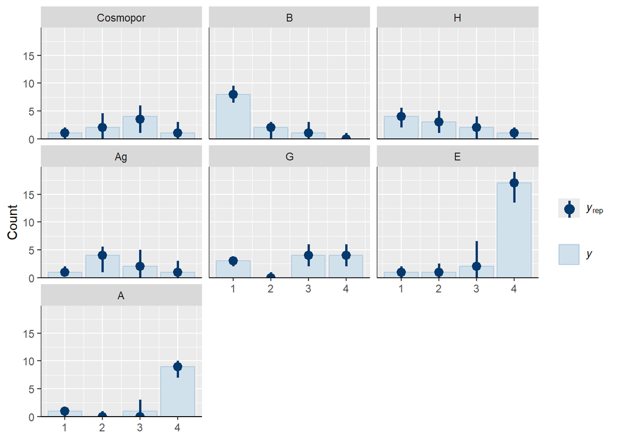

```
Computed from 12000 by 80 log-likelihood matrix.

         Estimate   SE
elpd_loo    -50.7  9.2
p_loo        20.8  5.4
looic       101.5 18.4
------
MCSE of elpd_loo is NA.
MCSE and ESS estimates assume MCMC draws (r_eff in [0.7, 1.5]).

Pareto k diagnostic values:
                         Count Pct.    Min. ESS
(-Inf, 0.7]   (good)     75    93.8%   1213
   (0.7, 1]   (bad)       4     5.0%   <NA>
   (1, Inf)   (very bad)  1     1.2%   <NA>
See help('pareto-k-diagnostic') for details.
```

```r
evaluate_bayesian_model(fit1.4.0)
```

`fit1.6.0`:  
Model summary:  
Posterior predictive check - bars grouped by treatment:  
Leave-one-out cross-validation information criterion:

**Open code**

```
 Family: acat
  Links: mu = probit
Formula: score2 ~ cs(treat) + log_CFU_mL2_s + (1 | batch/cage)
   Data: data1.2 (Number of observations: 80)
  Draws: 4 chains, each with iter = 4000; warmup = 1000; thin = 1;
         total post-warmup draws = 12000

Multilevel Hyperparameters:
~batch (Number of levels: 5)
              Estimate Est.Error l-95% CI u-95% CI Rhat Bulk_ESS Tail_ESS
sd(Intercept)     1.04      0.64     0.13     2.62 1.00     3492     2944

~batch:cage (Number of levels: 10)
              Estimate Est.Error l-95% CI u-95% CI Rhat Bulk_ESS Tail_ESS
sd(Intercept)     0.43      0.37     0.02     1.34 1.00     3893     5894

Regression Coefficients:
              Estimate Est.Error l-95% CI u-95% CI Rhat Bulk_ESS Tail_ESS
Intercept[1]     -1.82      0.84    -3.51    -0.23 1.00     6800     7927
Intercept[2]     -0.18      0.72    -1.61     1.23 1.00     5881     6747
Intercept[3]      1.97      0.73     0.58     3.48 1.00     5875     6596
log_CFU_mL2_s     2.54      0.46     1.68     3.47 1.00    10061     8859
treatB[1]        -0.88      1.06    -3.00     1.14 1.00    13517     9801
treatB[2]        -1.97      1.08    -4.17     0.07 1.00    12668     8599
treatB[3]        -2.00      1.39    -4.93     0.55 1.00    16322     8068
treatH[1]        -0.48      0.96    -2.39     1.38 1.00    11115     9697
treatH[2]        -1.01      0.85    -2.67     0.62 1.00    10967     9617
treatH[3]        -0.73      1.01    -2.81     1.17 1.00    13594     9374
treatAg[1]        0.86      1.36    -1.63     3.64 1.00    13265     9256
treatAg[2]       -1.08      0.76    -2.61     0.38 1.00    10756     9992
treatAg[3]       -0.46      1.05    -2.58     1.52 1.00    13655     8953
treatG[1]        -0.42      1.45    -3.35     2.28 1.00    14054     9140
treatG[2]         1.74      1.27    -0.50     4.46 1.00    13784     9425
treatG[3]         0.38      0.75    -1.10     1.85 1.00    10437     9579
treatE[1]         1.89      0.99    -0.08     3.84 1.00    11376     9148
treatE[2]         1.02      1.11    -1.06     3.27 1.00    12641     9021
treatE[3]         1.93      0.69     0.62     3.32 1.00     8370     8669
treatA[1]        -1.00      1.38    -3.80     1.63 1.00    14657     9685
treatA[2]         0.96      1.37    -1.51     3.74 1.00    13877     9291
treatA[3]         1.69      0.79     0.19     3.29 1.00     9622     8886

Further Distributional Parameters:
     Estimate Est.Error l-95% CI u-95% CI Rhat Bulk_ESS Tail_ESS
disc     1.00      0.00     1.00     1.00   NA       NA       NA

Draws were sampled using sampling(NUTS). For each parameter, Bulk_ESS
and Tail_ESS are effective sample size measures, and Rhat is the potential
scale reduction factor on split chains (at convergence, Rhat = 1).
```

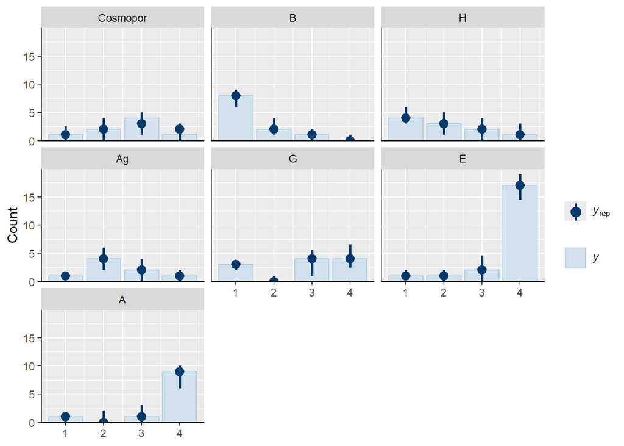

```
Computed from 12000 by 80 log-likelihood matrix.

         Estimate   SE
elpd_loo    -51.9  9.7
p_loo        22.4  5.9
looic       103.7 19.4
------
MCSE of elpd_loo is NA.
MCSE and ESS estimates assume MCMC draws (r_eff in [0.7, 1.4]).

Pareto k diagnostic values:
                         Count Pct.    Min. ESS
(-Inf, 0.7]   (good)     70    87.5%   537
   (0.7, 1]   (bad)       9    11.2%   <NA>
   (1, Inf)   (very bad)  1     1.2%   <NA>
See help('pareto-k-diagnostic') for details.
```

```r
evaluate_bayesian_model(fit1.6.0)
```

`fit1.7.0`:  
Model summary:  
Posterior predictive check - bars grouped by treatment:  
Leave-one-out cross-validation information criterion:

**Open code**

```
 Family: acat
  Links: mu = probit
Formula: score2 ~ cs(treat) + log_CFU_mL2_s + (1 | batch/cage/ID)
   Data: data1.2 (Number of observations: 80)
  Draws: 4 chains, each with iter = 4000; warmup = 1000; thin = 1;
         total post-warmup draws = 12000

Multilevel Hyperparameters:
~batch (Number of levels: 5)
              Estimate Est.Error l-95% CI u-95% CI Rhat Bulk_ESS Tail_ESS
sd(Intercept)     1.12      0.68     0.11     2.77 1.00     4257     3505

~batch:cage (Number of levels: 10)
              Estimate Est.Error l-95% CI u-95% CI Rhat Bulk_ESS Tail_ESS
sd(Intercept)     0.49      0.42     0.02     1.57 1.00     4544     6539

~batch:cage:ID (Number of levels: 40)
              Estimate Est.Error l-95% CI u-95% CI Rhat Bulk_ESS Tail_ESS
sd(Intercept)     0.78      0.47     0.04     1.81 1.00     2519     4492

Regression Coefficients:
              Estimate Est.Error l-95% CI u-95% CI Rhat Bulk_ESS Tail_ESS
Intercept[1]     -2.20      0.96    -4.16    -0.41 1.00     7923     8696
Intercept[2]     -0.23      0.76    -1.76     1.24 1.00     8157     8745
Intercept[3]      2.33      0.84     0.77     4.07 1.00     6704     7788
log_CFU_mL2_s     3.00      0.64     1.91     4.41 1.00     5947     7326
treatB[1]        -0.98      1.17    -3.36     1.27 1.00    13707     9850
treatB[2]        -2.15      1.15    -4.48     0.04 1.00    12427     9376
treatB[3]        -2.00      1.44    -5.02     0.64 1.00    15896     9282
treatH[1]        -0.44      1.07    -2.57     1.65 1.00    12905     9845
treatH[2]        -1.21      0.96    -3.16     0.60 1.00    10482     8763
treatH[3]        -0.93      1.17    -3.39     1.27 1.00    14468     9273
treatAg[1]        0.93      1.39    -1.61     3.82 1.00    15570     9798
treatAg[2]       -1.02      0.82    -2.64     0.56 1.00    11559    10224
treatAg[3]       -0.63      1.22    -3.10     1.62 1.00    14578     9035
treatG[1]        -0.57      1.50    -3.56     2.30 1.00    15193     8870
treatG[2]         1.73      1.32    -0.63     4.54 1.00    14048     8977
treatG[3]         0.35      0.88    -1.40     2.03 1.00    10884     9121
treatE[1]         2.09      1.13    -0.08     4.37 1.00    12123     9475
treatE[2]         1.36      1.23    -0.93     3.90 1.00    12687     7991
treatE[3]         2.32      0.85     0.76     4.11 1.00     7219     7942
treatA[1]        -0.87      1.50    -3.89     1.99 1.00    15792     9743
treatA[2]         1.05      1.43    -1.55     3.98 1.00    14529     8879
treatA[3]         1.98      0.96     0.22     3.98 1.00     9276     8747

Further Distributional Parameters:
     Estimate Est.Error l-95% CI u-95% CI Rhat Bulk_ESS Tail_ESS
disc     1.00      0.00     1.00     1.00   NA       NA       NA

Draws were sampled using sampling(NUTS). For each parameter, Bulk_ESS
and Tail_ESS are effective sample size measures, and Rhat is the potential
scale reduction factor on split chains (at convergence, Rhat = 1).
```

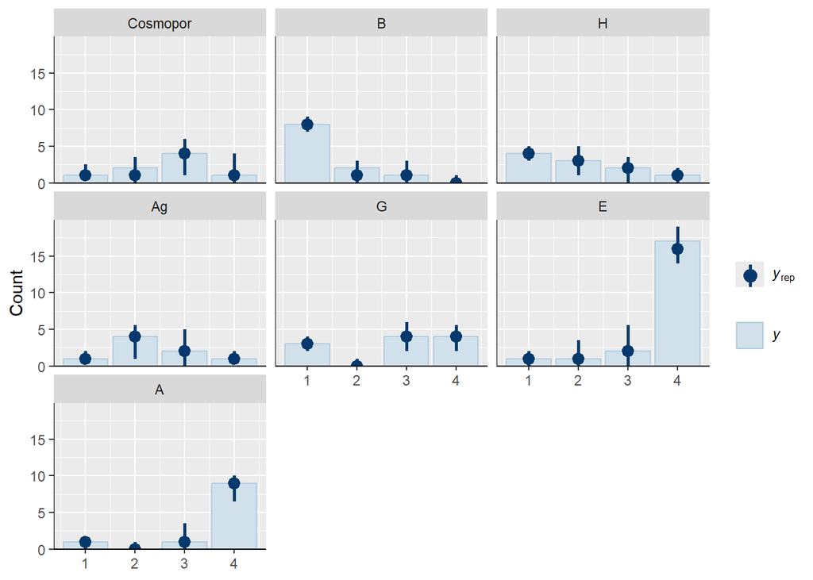

```
Computed from 12000 by 80 log-likelihood matrix.

         Estimate   SE
elpd_loo    -49.2  8.2
p_loo        25.5  5.4
looic        98.3 16.5
------
MCSE of elpd_loo is NA.
MCSE and ESS estimates assume MCMC draws (r_eff in [0.6, 1.3]).

Pareto k diagnostic values:
                         Count Pct.    Min. ESS
(-Inf, 0.7]   (good)     61    76.2%   476
   (0.7, 1]   (bad)      17    21.2%   <NA>
   (1, Inf)   (very bad)  2     2.5%   <NA>
See help('pareto-k-diagnostic') for details.
```

```r
evaluate_bayesian_model(fit1.7.0)
```

Let’s see if the introduction of random effects had an impact on the estimated fixed coefficients:

**Open code**

```r
df1.3.0 <-
  as.data.frame(fixef(fit1.3.0)) |>
  mutate(fit = "fit1.3.0") |>
  rownames_to_column(var = "RowOrder")

df1.4.0 <-
  as.data.frame(fixef(fit1.4.0)) |>
  mutate(fit = "fit1.4.0") |>
  rownames_to_column(var = "RowOrder")

df1.6.0 <-
  as.data.frame(fixef(fit1.6.0)) |>
  mutate(fit = "fit1.6.0") |>
  rownames_to_column(var = "RowOrder")

df1.7.0 <-
  as.data.frame(fixef(fit1.7.0)) |>
  mutate(fit = "fit1.7.0") |>
  rownames_to_column(var = "RowOrder")

# Comparison of modes: fixed effects only vs mixed effects
df <-
  do.call("rbind", list(df1.3.0, df1.4.0, df1.6.0, df1.7.0)) |>
  mutate(model_type = case_when(fit == "fit1.3.0" ~ "fixed",
                                .default = "mixed")) |>
  ggplot() +
  geom_point(aes(x = Estimate,
                 y = RowOrder,
                 group = model_type,
                 color = model_type),
             width=.1,
             position = position_dodge(width = 0.5)) +
  geom_errorbar(aes(x = Estimate,
                    xmin = Q2.5,
                    xmax = Q97.5,
                    y = RowOrder,
                    group = model_type,
                    color = model_type),
                width=.1,
                position = position_dodge(width = 0.5)) +
  geom_vline(xintercept = 0) +
  labs(title = "Comparison of fixed effects: fit1.3.0 vs [fit1.4.0, fit1.6.0, fit1.7.0]") +
  theme_bw()
```

**Open code**

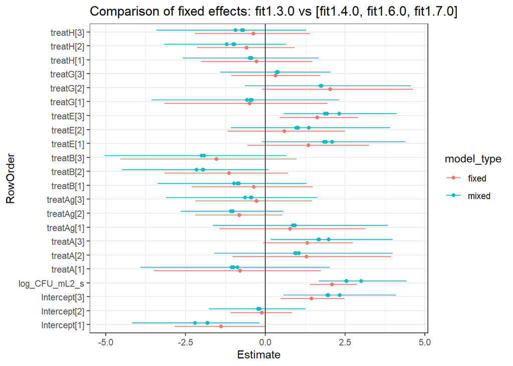

```r
df
```

**Open code**

```r
# Models with random effects:
df <-
  do.call("rbind", list(df1.4.0, df1.6.0, df1.7.0)) |>
  ggplot() +
  geom_point(aes(x = Estimate,
                 y = RowOrder,
                 group = fit,
                 color = fit),
             width=.1,
             position = position_dodge(width = 0.5)) +
  geom_errorbar(aes(x = Estimate,
                    xmin = Q2.5,
                    xmax = Q97.5,
                    y = RowOrder,
                    group = fit,
                    color = fit),
                width=.1,
                position = position_dodge(width = 0.5)) +
  geom_vline(xintercept = 0) +
  labs(title = "Comparison of fixed effects: fit1.4.0, fit1.6.0, fit1.7.0") +
  theme_bw()
```

**Open code**

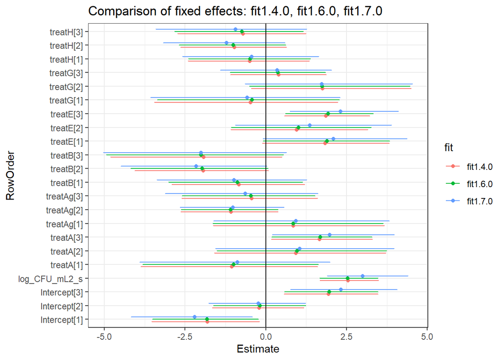

```r
df
```

The introduction of random effects led to more wider credible intervals. However, the overall patterns and directions of the fixed effects remained consistent across models.

The `fit1.7.0` includes the full nested random effects structure (1 ∣ `batch` / `cage` / `ID`), partitioning the unexplained variability into three distinct components (see Multilevel Hyperparameters). The results indicate that all three sources of grouping (`batch`, `cage` within `batch`, `ID` within `cage`) introduce non-zero variability. Thus, including these full nesting structure in the model seems to be reasonable.

Now we compare the predictive performance of the tested models:

**Open code**

```r
loo(fit1.1.0, fit1.2.0, fit1.3.0, fit1.4.0, fit1.6.0, fit1.7.0)
```

```
Output of model 'fit1.1.0':

Computed from 12000 by 80 log-likelihood matrix.

         Estimate  SE
elpd_loo   -108.1 3.6
p_loo         3.0 0.2
looic       216.1 7.1
------
MCSE of elpd_loo is 0.0.
MCSE and ESS estimates assume MCMC draws (r_eff in [0.4, 0.8]).

All Pareto k estimates are good (k < 0.7).
See help('pareto-k-diagnostic') for details.

Output of model 'fit1.2.0':

Computed from 12000 by 80 log-likelihood matrix.

         Estimate   SE
elpd_loo    -96.5  9.8
p_loo        21.5  3.5
looic       193.0 19.6
------
MCSE of elpd_loo is NA.
MCSE and ESS estimates assume MCMC draws (r_eff in [0.4, 1.5]).

Pareto k diagnostic values:
                         Count Pct.    Min. ESS
(-Inf, 0.7]   (good)     75    93.8%   544
   (0.7, 1]   (bad)       5     6.2%   <NA>
   (1, Inf)   (very bad)  0     0.0%   <NA>
See help('pareto-k-diagnostic') for details.

Output of model 'fit1.3.0':

Computed from 12000 by 80 log-likelihood matrix.

         Estimate   SE
elpd_loo    -58.3 11.0
```

[output cut: 63 more lines]

```
Pareto k diagnostic values:
                         Count Pct.    Min. ESS
(-Inf, 0.7]   (good)     61    76.2%   476
   (0.7, 1]   (bad)      17    21.2%   <NA>
   (1, Inf)   (very bad)  2     2.5%   <NA>
See help('pareto-k-diagnostic') for details.

Model comparisons:
         elpd_diff se_diff
fit1.7.0   0.0       0.0
fit1.4.0  -1.6       1.5
fit1.6.0  -2.7       2.0
fit1.3.0  -9.1       4.4
fit1.2.0 -47.3       8.0
fit1.1.0 -58.9       7.6
```

Since the elpd (Estimated Log Predictive Density) provided by *loo()* relies on statistical approximation (Pareto Smoothing - PSIS), the Pareto k values help us assess the reliability of the elpd calculation for each model. Values approaching or exceeding 0.7 indicate highly influential data points that can make the LOOIC estimation unstable. E.g.,

- `fit1.4.0`: 5% fell into the “bad” region (0.7, 1) and 1.2 % into “very bad” region (k > 1)
- `fit1.6.0`: 11.2% “bad”, 1.2% “very bad”
- `fit1.7.0`: 21.2% “bad”, 2.5% “very bad”

Solution:

- identify the problematic values and check for any obvious errors or typos in primary data
- compute exact cross-validation for problematic observations using *reloo()*

#### 2.6.1.5 Check high Pareto k points

**Identification of problematic datapoints**

First, let’s find and investigate the data points with high Pareto k for the most interesting fits.  
Each fit provides a slightly different set of “problematic” values. SO, find them all and plot it:

**Open code**

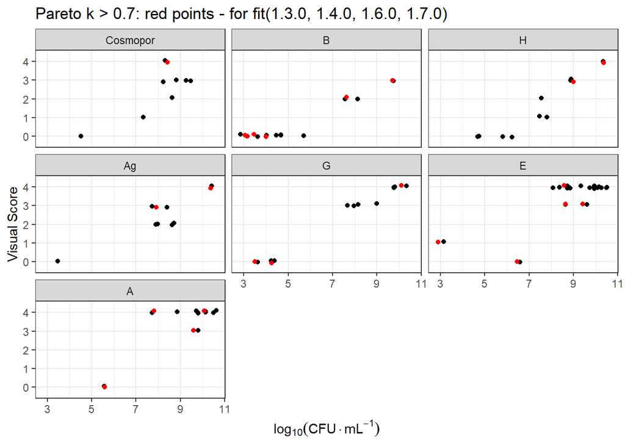

```r
# Get the LOOIC results
pareto_1.3.0 <- loo(fit1.3.0)
pareto_1.4.0 <- loo(fit1.4.0)
pareto_1.6.0 <- loo(fit1.6.0)
pareto_1.7.0 <- loo(fit1.7.0)

# Indentify the problematic Pareto k (k > 0.7)
problem_1.3.0 <-
  pareto_1.3.0$pointwise |>
  data.frame() |>
  rowid_to_column() |>
  filter(influence_pareto_k > 0.7) |>
  pull(rowid)

problem_1.4.0 <-
  pareto_1.4.0$pointwise |>
  data.frame() |>
  rowid_to_column() |>
  filter(influence_pareto_k > 0.7) |>
  pull(rowid)

problem_1.6.0 <-
  pareto_1.6.0$pointwise |>
  data.frame() |>
  rowid_to_column() |>
  filter(influence_pareto_k > 0.7) |>
  pull(rowid)

problem_1.7.0 <-
  pareto_1.7.0$pointwise |>
  data.frame() |>
  rowid_to_column() |>
  filter(influence_pareto_k > 0.7) |>
  pull(rowid)

# Find and save only the unique observations with Pareto k > 0.7
all_problems <- unique(c(problem_1.3.0, problem_1.4.0, problem_1.6.0, problem_1.7.0))

# Exclude datapoints with Pareto k > 0.7 - we will use it leter to re-run the models
data1.2_pareto <-
  data1.2 |>
  mutate(rowindex = 1:length(data1.2$ID)) |>
  mutate(problems = 0) |>
  filter(!rowindex %in% all_problems)

# Keep only when Pareto k > 0.7
data1.2_pareto_keep <-
  data1.2 |>
  mutate(rowindex = 1:length(data1.2$ID)) |>
  mutate(problems = 0) |>
  filter(rowindex %in% all_problems)

ggplot() +
  geom_jitter(data = data1.2,
              mapping = aes(x = log_CFU_mL2, y = score),
              colour = "black",
              width = 0.2,
              height = 0.1,
              alpha = 1) +
    geom_jitter(data = data1.2_pareto_keep,
              mapping = aes(x = log_CFU_mL2, y = score),
              colour = "red",
              width = 0.2,
              height = 0.1,
              alpha = 1) +
  labs(
    title = "Pareto k > 0.7: red points - for fit(1.3.0, 1.4.0, 1.6.0, 1.7.0)",
    x = bquote(log[10](CFU%.%mL^-1)),
    y = "Visual Score"
  ) +
  theme_bw() +
  facet_wrap(~treat)
```

Couldn’t spot any obvious errors or typos in the original data for the problematic observations (red points). They seem to be valid measurements.

**Compute exact cross-validation**

Re-run the model(s) for the problematic observations.

**Open code**

```r
loo1.3.0 <- loo(fit1.3.0)
reloo1.3.0 <- reloo(fit1.3.0, loo = loo1.3.0, chains = 2)

loo1.4.0 <- loo(fit1.4.0)
reloo1.4.0 <- reloo(fit1.4.0, loo = loo1.4.0, chains = 2)

loo1.6.0 <- loo(fit1.6.0)
reloo1.6.0 <- reloo(fit1.6.0, loo = loo1.6.0, chains = 2)

loo1.7.0 <- loo(fit1.7.0)
reloo1.7.0 <- reloo(fit1.7.0, loo = loo1.7.0, chains = 2)

save(reloo1.3.0, file = "b_reloo1.3.0.RData")
save(reloo1.4.0, file = "b_reloo1.4.0.RData")
save(reloo1.6.0, file = "b_reloo1.6.0.RData")
save(reloo1.7.0, file = "b_reloo1.7.0.RData")
```

**Open code**

```r
# Final results
reloo1.3.0
```

```
Computed from 12000 by 80 log-likelihood matrix.

         Estimate   SE
elpd_loo    -60.2 12.0
p_loo        22.4  7.2
looic       120.4 24.1
------
MCSE of elpd_loo is 0.4.
MCSE and ESS estimates assume MCMC draws (r_eff in [0.4, 1.6]).

All Pareto k estimates are good (k < 0.7).
See help('pareto-k-diagnostic') for details.
```

**Open code**

```r
reloo1.4.0
```

```
Computed from 12000 by 80 log-likelihood matrix.

         Estimate   SE
elpd_loo    -52.3 10.1
p_loo        22.4  6.4
looic       104.6 20.2
------
MCSE of elpd_loo is 0.3.
MCSE and ESS estimates assume MCMC draws (r_eff in [0.7, 1.5]).

All Pareto k estimates are good (k < 0.7).
See help('pareto-k-diagnostic') for details.
```

**Open code**

```r
reloo1.6.0
```

```
Computed from 12000 by 80 log-likelihood matrix.

         Estimate   SE
elpd_loo    -54.4 11.1
p_loo        25.0  7.5
looic       108.9 22.2
------
MCSE of elpd_loo is 0.4.
MCSE and ESS estimates assume MCMC draws (r_eff in [0.7, 1.4]).

All Pareto k estimates are good (k < 0.7).
See help('pareto-k-diagnostic') for details.
```

**Open code**

```r
reloo1.7.0
```

```
Computed from 12000 by 80 log-likelihood matrix.

         Estimate   SE
elpd_loo    -52.6 10.3
p_loo        29.0  7.7
looic       105.2 20.6
------
MCSE of elpd_loo is 0.4.
MCSE and ESS estimates assume MCMC draws (r_eff in [0.6, 1.3]).

All Pareto k estimates are good (k < 0.7).
See help('pareto-k-diagnostic') for details.
```

**Open code**

```r
# Compare the models
loo_compare(x = list(reloo1.3.0, reloo1.4.0, reloo1.6.0, reloo1.7.0))
```

```
         elpd_diff se_diff
fit1.4.0  0.0       0.0
fit1.7.0 -0.3       1.2
fit1.6.0 -2.2       1.2
fit1.3.0 -7.9       3.9
```

We can see that all Pareto k estimates (for `fit1.3.0`, `fit1.4.0`, `fit1.6.0`, `fit1.7.0`) are good (k < 0.7) after computing the exact cross-validation.

#### 2.6.1.6 Fit1.8.0

Fixed + random effects with interaction (`treat`:`log_CFU_mL2_s`)

Including the interaction between treatment and standardized microbial load.

The interaction `treat`:`log_CFU_mL2_s` allows situations when the quality (virulence) of the bacteria or the host’s tolerance to them can be modified by the treatment:

> 1. Treatment can disrupts bacterial quality (e.g., biofilm) making the same CFU count less clinically detrimental (a flatter slope).
> 2. Treatment offers secondary effects (e.g., anti-inflammation) making the host more tolerant of a given CFU load (a flatter slope).

These are hypotheses. With the following model (`fit1.8.0`), we primarily want to verify whether there will be a dramatic change in the resulting predictions.

**Open code**

```r
data1.2 <-
  data1.2 |>
  mutate(treat = relevel(treat, ref = "Cosmopor"))

fit1.8.0 <- update(fit1.7.0,
                   newdata = data1.2,
                   formula = bf(score2 ~ 1 + cs(treat) + log_CFU_mL2_s + treat:log_CFU_mL2_s + (1 | batch / cage / ID)))

save(fit1.8.0, file = "b_fit1.8.0.RData")
```

`fit1.8.0`:  
Model summary:  
Posterior predictive check - bars grouped by treatment:  
Leave-one-out cross-validation information criterion:

**Open code**

```
 Family: acat
  Links: mu = probit
Formula: score2 ~ cs(treat) + log_CFU_mL2_s + (1 | batch/cage/ID) + log_CFU_mL2_s:treat
   Data: data1.2 (Number of observations: 80)
  Draws: 4 chains, each with iter = 4000; warmup = 1000; thin = 1;
         total post-warmup draws = 12000

Multilevel Hyperparameters:
~batch (Number of levels: 5)
              Estimate Est.Error l-95% CI u-95% CI Rhat Bulk_ESS Tail_ESS
sd(Intercept)     1.11      0.71     0.10     2.84 1.00     4579     4098

~batch:cage (Number of levels: 10)
              Estimate Est.Error l-95% CI u-95% CI Rhat Bulk_ESS Tail_ESS
sd(Intercept)     0.52      0.43     0.02     1.63 1.00     4850     6654

~batch:cage:ID (Number of levels: 40)
              Estimate Est.Error l-95% CI u-95% CI Rhat Bulk_ESS Tail_ESS
sd(Intercept)     0.70      0.46     0.03     1.74 1.00     2781     4997

Regression Coefficients:
                      Estimate Est.Error l-95% CI u-95% CI Rhat Bulk_ESS
Intercept[1]             -2.46      0.98    -4.45    -0.64 1.00    10109
Intercept[2]             -0.26      0.78    -1.85     1.25 1.00     9306
Intercept[3]              2.44      0.85     0.86     4.22 1.00     8008
log_CFU_mL2_s             3.11      0.82     1.61     4.87 1.00     8367
log_CFU_mL2_s:treatB      0.77      1.29    -1.64     3.38 1.00    12676
log_CFU_mL2_s:treatH      2.15      1.35    -0.36     4.93 1.00    13520
log_CFU_mL2_s:treatAg     0.46      1.37    -2.12     3.32 1.00    14197
log_CFU_mL2_s:treatG      2.04      1.39    -0.53     4.88 1.00    13008
log_CFU_mL2_s:treatE     -1.20      0.90    -2.97     0.57 1.00    10102
log_CFU_mL2_s:treatA      0.61      1.21    -1.61     3.14 1.00    10936
treatB[1]                -0.82      1.35    -3.44     1.92 1.00    14918
treatB[2]                -2.24      1.19    -4.68    -0.02 1.00    16087
treatB[3]                -2.22      1.49    -5.25     0.61 1.00    15459
treatH[1]                 0.28      1.31    -2.26     2.87 1.00    13884
treatH[2]                -1.46      1.01    -3.53     0.48 1.00    13449
treatH[3]                -1.65      1.30    -4.29     0.79 1.00    16449
treatAg[1]                0.78      1.48    -1.89     3.87 1.00    17165
treatAg[2]               -1.07      0.84    -2.75     0.55 1.00    13148
```

[output cut: 32 more lines]

```
treatG[3]                 8876
treatE[1]                 9428
treatE[2]                 8708
treatE[3]                 9860
treatA[1]                 9058
treatA[2]                10020
treatA[3]                 9472

Further Distributional Parameters:
     Estimate Est.Error l-95% CI u-95% CI Rhat Bulk_ESS Tail_ESS
disc     1.00      0.00     1.00     1.00   NA       NA       NA

Draws were sampled using sampling(NUTS). For each parameter, Bulk_ESS
and Tail_ESS are effective sample size measures, and Rhat is the potential
scale reduction factor on split chains (at convergence, Rhat = 1).
```

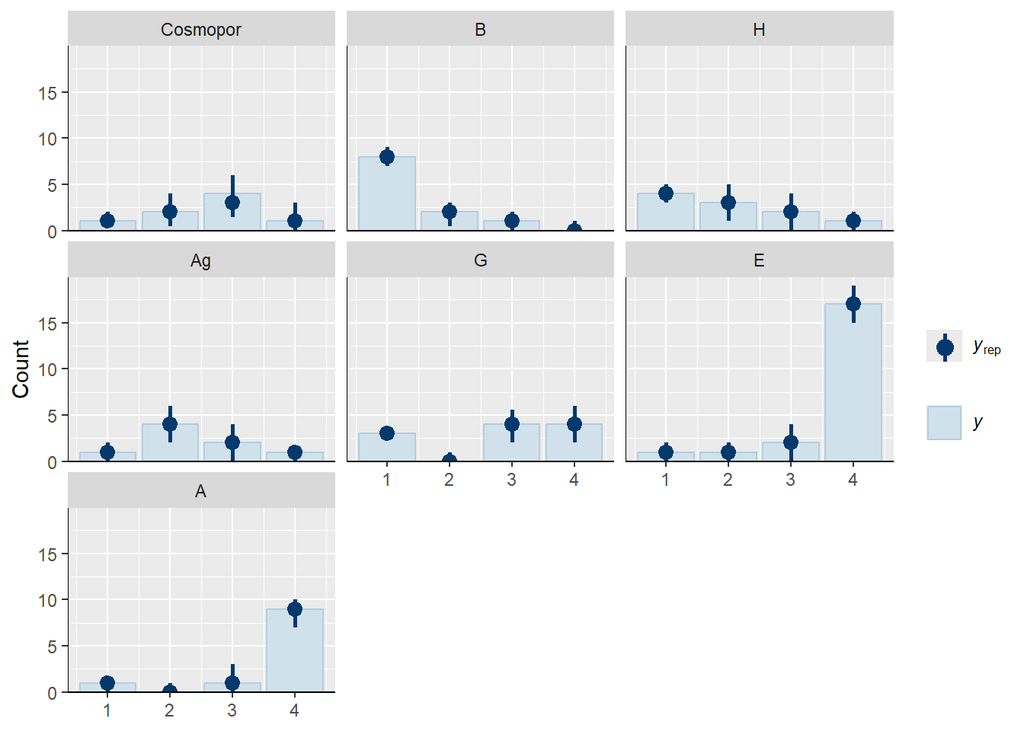

```
Computed from 12000 by 80 log-likelihood matrix.

         Estimate   SE
elpd_loo    -44.7  7.2
p_loo        23.5  4.5
looic        89.5 14.4
------
MCSE of elpd_loo is NA.
MCSE and ESS estimates assume MCMC draws (r_eff in [0.7, 1.3]).

Pareto k diagnostic values:
                         Count Pct.    Min. ESS
(-Inf, 0.7]   (good)     57    71.2%   211
   (0.7, 1]   (bad)      17    21.2%   <NA>
   (1, Inf)   (very bad)  6     7.5%   <NA>
See help('pareto-k-diagnostic') for details.
```

```r
evaluate_bayesian_model(fit1.8.0)
```

See the comparison of model estimates with and without interaction term.

**Open code**

```r
df1.7.0 <-
  as.data.frame(fixef(fit1.7.0)) |>
  mutate(fit = "fit1.7.0") |>
  rownames_to_column(var = "RowOrder")

df1.8.0 <-
  as.data.frame(fixef(fit1.8.0)) |>
  mutate(fit = "fit1.8.0") |>
  rownames_to_column(var = "RowOrder")

df <-
  do.call("rbind", list(df1.7.0, df1.8.0)) |>
  ggplot() +
  geom_point(aes(x = Estimate,
                 y = RowOrder,
                 group = fit,
                 color = fit),
             width=.1,
             position = position_dodge(width = 0.5)) +
  geom_errorbar(aes(x = Estimate,
                    xmin = Q2.5,
                    xmax = Q97.5,
                    y = RowOrder,
                    group = fit,
                    color = fit),
                width=.1,
                position = position_dodge(width = 0.5)) +
  geom_vline(xintercept = 0) +
  labs(title = "fit1.7.0 (no interactions) vs fit1.8.0 (with interactions)" )  +
  theme_bw()
```

**Open code**

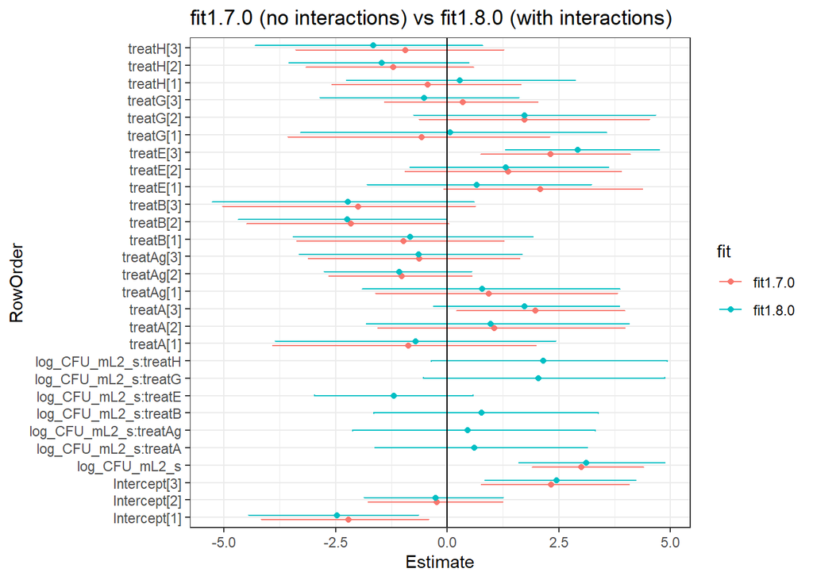

```r
df
```

We have no strong prior evidence that treatments alter the slope of the CFU-to-score relationship differently. In addition, the interaction coefficients exhibit high posterior uncertainty with widely overlapping zero. The simpler additive structure (e.g., `fit1.7.0`) likely provides more robust estimates given the sample size.

And compare the predictive power of `fit1.7.0` and `fit1.8.0`:

**Open code**

```r
loo1.8.0 <- loo(fit1.8.0)
reloo1.8.0 <- reloo(fit1.8.0, loo = loo1.8.0, chains = 2)

save(reloo1.8.0, file = "b_reloo1.8.0.RData")

# Final results
reloo1.8.0
```

[output not shown]

**Open code**

```r
# Compare the models
loo_compare(x = list(reloo1.7.0, reloo1.8.0))
```

```
         elpd_diff se_diff
fit1.8.0  0.0       0.0
fit1.7.0 -4.2       2.9
```

#### 2.6.1.7 Discussion and conclusion

**Overview of tested models**

Fixed effects only:  
- `fit1.1.0`: score ~ 1  
- `fit1.2.0`: score ~ 1 + cs(treat)  
- `fit1.3.0`: score ~ 1 + cs(treat) + log_CFU_mL_s

Fixed + random effects:  
- `fit1.4.0`: score ~ 1 + cs(treat) + log_CFU_mL_s + (1 | batch)  
- `fit1.6.0`: score ~ 1 + cs(treat) + log_CFU_mL_s + (1 | batch / cage)  
- `fit1.7.0`: score ~ 1 + cs(treat) + log_CFU_mL_s + (1 | batch / cage / ID)  
- `fit1.8.0`: score ~ 1 + cs(treat) + log_CFU_mL_s + treat:log_CFU_mL_s + (1 | batch / cage / ID)

**Discussion and conclusion**

We found that `log_CFU_mL2_s` represents an important covariate in terms of predictive accuracy, as assessed by the LOOIC (see comparison of `fit1.2.0` and `fit1.3.0`). Incorporation of `batch` as a random effect (fit1.4.0) slightly improved the predictive power compared to `fit1.3.0`.

Further incorporation of `cage` and `ID` did not dramatically improve LOOIC compared to `fit1.4.0` (`fit1.4.0`, `fit1.6.0` and `fit1.7.0` yielded similar values). In contrast, the estimated multilevel hyperparameters for `fit1.7.0` indicate that all three sources of grouping (`batch`, `cage`, `ID`) introduce non-zero variability. Thus, including this full nesting structure in the model seems reasonable.

Since we were not facing any serious computational troubles for all models (MCMC convergence and posterior predictive checks were fine), we chose as the final candidate `fit1.7.0`, which respects the experimental design.

Model `fit1.7.0` remains stable when choosing more diffuse/tighter initial priors (see Sensitivity analysis below) and for the choice of the logit link function (link sensitivity below).

##### Sensitivity analysis - prior sensitivity

Check for different prior setting for `fit1.7.0`.

**Open code**

```r
# ----------------------------------------------------------------------
# 1. Highly Diffuse Prior (Normal(0, 5)).
# ----------------------------------------------------------------------
prior_diffuse <- c(
    prior(normal(0, 5), class = Intercept),
    prior(normal(0, 5), class = b, coef = "treat"),
    prior(normal(0, 5), class = b, coef = "log_CFU_mL2_s")
)

fit1.7.1 <- update(fit1.7.0,
                   prior = prior_diffuse)

save(fit1.7.1, file = "b_fit1.7.1.RData")


# ----------------------------------------------------------------------
# 2. Tighter/Skeptical Prior (Normal(0, 1))
# ----------------------------------------------------------------------
prior_tight <- c(
    prior(normal(0, 1), class = Intercept),
    prior(normal(0, 1), class = b, coef = "treat"),
    prior(normal(0, 1), class = b, coef = "log_CFU_mL_s")
)

fit1.7.2 <- update(fit1.7.0,
                   prior = prior_tight)

save(fit1.7.2, file = "b_fit1.7.2.RData")
```

See the results for the prior sensitivity analysis:

**Open code**

```r
df1.7.0 <-
  as.data.frame(fixef(fit1.7.0)) |>
  mutate(fit = "fit1.7.0") |>
  rownames_to_column(var = "RowOrder")

df1.7.1 <-
  as.data.frame(fixef(fit1.7.1)) |>
  mutate(fit = "fit1.7.1") |>
  rownames_to_column(var = "RowOrder")

df1.7.2 <-
  as.data.frame(fixef(fit1.7.2)) |>
  mutate(fit = "fit1.7.2") |>
  rownames_to_column(var = "RowOrder")

df <-
  do.call("rbind", list(df1.7.0, df1.7.1, df1.7.2)) |>
  ggplot() +
  geom_point(aes(x = Estimate,
                 y = RowOrder,
                 group = fit,
                 color = fit),
             width=.1,
             position = position_dodge(width = 0.5)) +
  geom_errorbar(aes(x = Estimate,
                    xmin = Q2.5,
                    xmax = Q97.5,
                    y = RowOrder,
                    group = fit,
                    color = fit),
                width=.1,
                position = position_dodge(width = 0.5)) +
  geom_vline(xintercept = 0) +
  labs(title = "Initial prior vs Diffuse Prior vs  Tighter prior") +
  theme_bw()
```

**Open code**

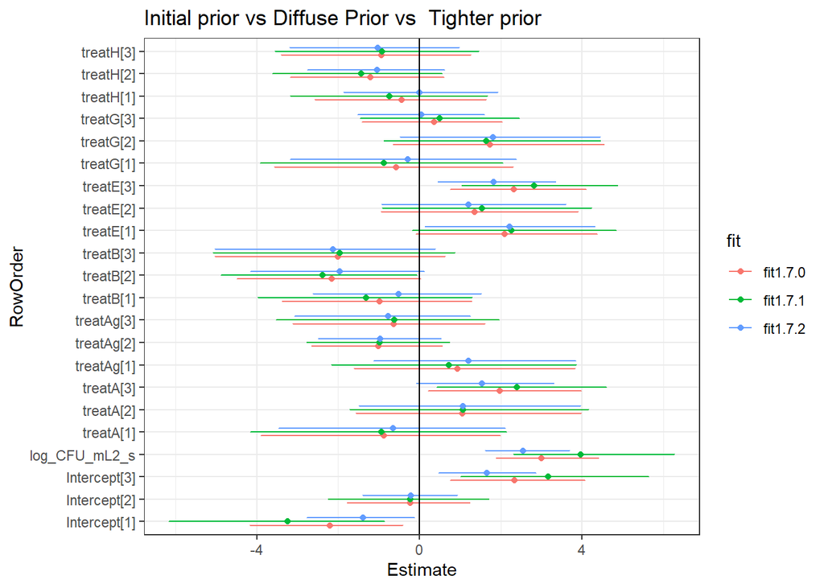

```r
df
```

Results seem to be reasonably stable.

##### Sensitivity analysis - link function

Are the results sensitive to the choice of the link function? - Comparison of probit and logit link functions.

**Open code**

```r
set.seed = 225

fit1.7.3 <- update(fit1.7.0,
                   newdata = data1.2,
                   family = acat("logit"))

fit1.7.3 <- add_criterion(fit1.7.3, "loo")

save(fit1.7.3, file = "b_fit1.7.3.RData")
```

**Open code**

```r
df1.7.0 <-
  as.data.frame(fixef(fit1.7.0)) |>
  mutate(fit = "fit1.7.0") |>
  rownames_to_column(var = "RowOrder")

df1.7.3 <-
  as.data.frame(fixef(fit1.7.3)) |>
  mutate(fit = "fit1.7.3") |>
  rownames_to_column(var = "RowOrder")

df <-
  do.call("rbind", list(df1.7.0, df1.7.3)) |>
  ggplot() +
  geom_point(aes(x = Estimate,
                 y = RowOrder,
                 group = fit,
                 color = fit),
             width=.1,
             position = position_dodge(width = 0.5)) +
  geom_errorbar(aes(x = Estimate,
                    xmin = Q2.5,
                    xmax = Q97.5,
                    y = RowOrder,
                    group = fit,
                    color = fit),
                width=.1,
                position = position_dodge(width = 0.5)) +
  geom_vline(xintercept = 0) +
  labs(title = "probit vs logit") +
  theme_bw()
```

**Open code**

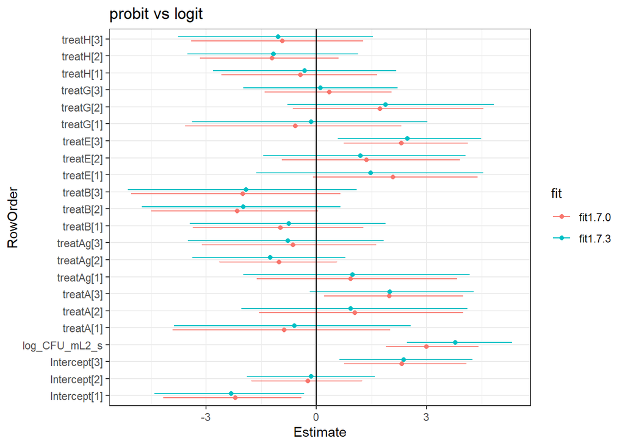

```r
df
```

The link function is not a game changer here - results are stable.

## 2.7 Mediator model (M)

**Open code**

```r
set.seed = 225

bm2.1.0 <- bf(log_CFU_mL2_s ~ 1 + treat + (1 | batch / cage / ID))

fit2.1.0  <- brm(bm2.1.0,
             data = data1.2,
             family = gaussian(),
             warmup = 1000,
             iter = 4000,
             chains = 4,
             cores = 10,
             control = list(adapt_delta = 0.99, max_treedepth = 15),
             #save_all_pars = TRUE,
             sample_prior = TRUE,
                             prior = c(prior(normal(0, 1), class = Intercept),
                             prior(normal(0, 1), class = b, coef = "treatA"),
                             prior(normal(0, 1), class = b, coef = "treatAg"),
                             prior(normal(0, 1), class = b, coef = "treatB"),
                             prior(normal(0, 1), class = b, coef = "treatE"),
                             prior(normal(0, 1), class = b, coef = "treatG"),
                             prior(normal(0, 1), class = b, coef = "treatH")))

fit2.1.0 <- add_criterion(fit2.1.0, "loo")

save(fit2.1.0, file = "b_fit2.1.0.RData")
```

`fit2.1.0`:  
Model summary:  
Posterior predictive check:  
Leave-one-out cross-validation information criterion:

**Open code**

```r
  ###  Summary of a fitted model
  print(summary(fit2.1.0))
```

```
 Family: gaussian
  Links: mu = identity
Formula: log_CFU_mL2_s ~ 1 + treat + (1 | batch/cage/ID)
   Data: data1.2 (Number of observations: 80)
  Draws: 4 chains, each with iter = 4000; warmup = 1000; thin = 1;
         total post-warmup draws = 12000

Multilevel Hyperparameters:
~batch (Number of levels: 5)
              Estimate Est.Error l-95% CI u-95% CI Rhat Bulk_ESS Tail_ESS
sd(Intercept)     0.43      0.34     0.03     1.29 1.00     3265     3911

~batch:cage (Number of levels: 10)
              Estimate Est.Error l-95% CI u-95% CI Rhat Bulk_ESS Tail_ESS
sd(Intercept)     0.36      0.21     0.03     0.86 1.00     3032     3326

~batch:cage:ID (Number of levels: 40)
              Estimate Est.Error l-95% CI u-95% CI Rhat Bulk_ESS Tail_ESS
sd(Intercept)     0.29      0.16     0.02     0.61 1.00     2406     4057

Regression Coefficients:
          Estimate Est.Error l-95% CI u-95% CI Rhat Bulk_ESS Tail_ESS
Intercept    -0.00      0.35    -0.68     0.69 1.00     4805     6324
treatB       -1.09      0.32    -1.71    -0.46 1.00     6253     7980
treatH       -0.29      0.33    -0.94     0.35 1.00     6401     8258
treatAg      -0.04      0.32    -0.68     0.58 1.00     8510     8957
treatG       -0.12      0.32    -0.76     0.50 1.00     6002     7550
treatE        0.43      0.29    -0.13     1.00 1.00     5193     6793
treatA        0.62      0.32    -0.01     1.26 1.00     6254     7902

Further Distributional Parameters:
      Estimate Est.Error l-95% CI u-95% CI Rhat Bulk_ESS Tail_ESS
sigma     0.71      0.08     0.57     0.88 1.00     3878     5335

Draws were sampled using sampling(NUTS). For each parameter, Bulk_ESS
and Tail_ESS are effective sample size measures, and Rhat is the potential
scale reduction factor on split chains (at convergence, Rhat = 1).
```

**Open code**

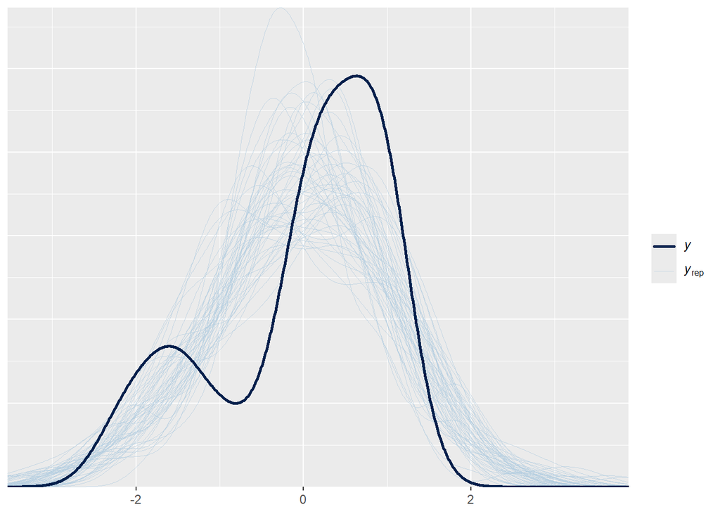

```r
  ### Distribution of outcome vs. newly simulated data distribution
  print(pp_check(fit2.1.0, ndraws = 50))
```

**Open code**

```r
  ### "Leave-one-out extreme value diagnostic"
  print(loo(fit2.1.0))
```

```
Computed from 12000 by 80 log-likelihood matrix.

         Estimate   SE
elpd_loo    -99.1  7.2
p_loo        21.5  3.3
looic       198.2 14.3
------
MCSE of elpd_loo is NA.
MCSE and ESS estimates assume MCMC draws (r_eff in [0.3, 1.4]).

Pareto k diagnostic values:
                         Count Pct.    Min. ESS
(-Inf, 0.7]   (good)     79    98.8%   438
   (0.7, 1]   (bad)       1     1.2%   <NA>
   (1, Inf)   (very bad)  0     0.0%   <NA>
See help('pareto-k-diagnostic') for details.
```

The observed bacterial load exhibits a bimodality, likely reflecting a biological divergence between “responding” animals (lower CFU) and those with persistent infections (higher CFU). While the Gaussian likelihood is inherently unimodal and produces a smoother, monomodal predictive distribution, the model captures the central tendency and the overall spread of the population data.

## 2.8 Joint model (Y + M)

**Open code**

```r
# Joint model:

# (A): model for outcome
# fit1.7.0 <- bf(score2 ~ 1 + cs(treat) + log_CFU_mL2_s + (1 | batch / cage / ID)))
bf_score <- bf(score2 ~ 1 + cs(treat) + log_CFU_mL2_s + (1 | batch / cage / ID),
               family = acat("probit"))

# (B) model for mediator
# fit2.1.0 <- bf(log_CFU_mL2_s ~ 1 + treat + (1 | batch / cage / ID))
bf_cfu <- bf(log_CFU_mL2_s ~ 1 + treat + (1 | batch / cage / ID),
             family = gaussian())

priors <- c(
  prior(normal(0, 1), class = b, resp = "logCFUmL2s"),
  prior(normal(0, 1), class = b, resp = "score2")
)

fit_joint <- brm(
  bf_score + bf_cfu,
  data = data1.2,
  warmup = 1000,
  iter = 4000,
  chains = 4,
  cores = 10,
  control = list(adapt_delta = 0.99, max_treedepth = 15),
  prior = priors,
  sample_prior = "yes"
)

save(fit_joint, file = "fit_joint.RData")
```

`fit_joint`:  
Model summary:  
Posterior predictive check:

**Open code**

```r
  ###  Summary of a fitted model
  print(summary(fit_joint))
```

```
 Family: MV(acat, gaussian)
  Links: mu = probit
         mu = identity
Formula: score2 ~ 1 + cs(treat) + log_CFU_mL2_s + (1 | batch/cage/ID)
         log_CFU_mL2_s ~ 1 + treat + (1 | batch/cage/ID)
   Data: data1.2 (Number of observations: 80)
  Draws: 4 chains, each with iter = 4000; warmup = 1000; thin = 1;
         total post-warmup draws = 12000

Multilevel Hyperparameters:
~batch (Number of levels: 5)
                         Estimate Est.Error l-95% CI u-95% CI Rhat Bulk_ESS
sd(score2_Intercept)         0.75      0.54     0.05     2.10 1.00     3530
sd(logCFUmL2s_Intercept)     0.45      0.36     0.02     1.35 1.00     3633
                         Tail_ESS
sd(score2_Intercept)         4200
sd(logCFUmL2s_Intercept)     4835

~batch:cage (Number of levels: 10)
                         Estimate Est.Error l-95% CI u-95% CI Rhat Bulk_ESS
sd(score2_Intercept)         0.32      0.28     0.01     1.01 1.00     4945
sd(logCFUmL2s_Intercept)     0.36      0.22     0.03     0.86 1.00     3152
                         Tail_ESS
sd(score2_Intercept)         5049
sd(logCFUmL2s_Intercept)     4857

~batch:cage:ID (Number of levels: 40)
                         Estimate Est.Error l-95% CI u-95% CI Rhat Bulk_ESS
sd(score2_Intercept)         0.33      0.25     0.01     0.92 1.00     3955
sd(logCFUmL2s_Intercept)     0.29      0.16     0.02     0.60 1.00     2378
                         Tail_ESS
sd(score2_Intercept)         5522
sd(logCFUmL2s_Intercept)     3920

Regression Coefficients:
                     Estimate Est.Error l-95% CI u-95% CI Rhat Bulk_ESS
score2_Intercept[1]     -1.61      0.72    -3.11    -0.27 1.00     7773
score2_Intercept[2]     -0.06      0.59    -1.22     1.09 1.00     5984
score2_Intercept[3]      1.46      0.62     0.31     2.73 1.00     5590
logCFUmL2s_Intercept    -0.01      0.38    -0.76     0.73 1.00     4618
```

[output cut: 49 more lines]

```
score2_treatE[1]         9724
score2_treatE[2]         9653
score2_treatE[3]         9852
score2_treatA[1]         9332
score2_treatA[2]         8963
score2_treatA[3]         9568

Further Distributional Parameters:
                 Estimate Est.Error l-95% CI u-95% CI Rhat Bulk_ESS Tail_ESS
disc_score2          1.00      0.00     1.00     1.00   NA       NA       NA
sigma_logCFUmL2s     0.72      0.08     0.58     0.88 1.00     4811     7509

Draws were sampled using sampling(NUTS). For each parameter, Bulk_ESS
and Tail_ESS are effective sample size measures, and Rhat is the potential
scale reduction factor on split chains (at convergence, Rhat = 1).
```

Interpretation:  
- B reduces log_CFU by 1.09 SD more than Cosmopor ($\color{pink}{\text{logCFUmL2s\_treatB}}$)  
- B shifts 0→1 threshold by −0.57 more than Cosmopor ($\color{pink}{\text{score2\_treatB[1]}}$)  
- each 1-SD increase in CFU → 2.13 increase in wound latent score ($\color{pink}{\text{score2\_log\_CFU\_mL2\_s}}$)

## 2.9 ADRESSING BIOLOGICAL QUESTIONS

### 2.9.1 Antimicrobial vs Tissue effect?

Proportional mediation via potential outcomes using joint model (Section 2.8):

- Total treatment effect decomposition for **B** vs **A**
- **B** vs **A** provides most noticeable treatment effect -> selected for decomposition
- Total treatment effect = direct effect (tissue effect; e.g. barrier support) + indirect effect (antimicrobial) - see Section 1.3
- **B** is active treatment, **A** is is non-active control
- Average Conditional Direct Effect: ACDE = E[score | B, CFU=μ_A] − E[score | A, CFU=μ_A]
- Average Conditional Indirect Effect: ACIE = E[score | B, CFU=μ_B] − E[score | B, CFU=μ_A]
- TOTAL EFFECT = ACDE + ACIE

**Open code**

```r
# ==============================================================================
#  CAUSAL MEDIATION ANALYSIS
# Framework: Potential Outcomes via brms::posterior_epred()
# Level: Population-Level Effects (re_formula = NA)
# ==============================================================================


# ==============================================================================
# --- 1. CONFIGURATION ---
# ==============================================================================
base_treat   <- "A"        # Baseline treatment (e.g., PVA without active molecule)
target_treat <- "B"        # Target treatment (e.g., PVA with active molecule)

# ==============================================================================W
# --- 2. HELPER FUNCTION: Expected Score from Ordinal Probabilities ---
# ==============================================================================
# Conceptul understanding of "Expected Score":
# Suppose we have a single mouse, draw 1, and 4 categories (0,1,2,3):
# P(score=0) = 0.75
# P(score=1) = 0.20
# P(score=2) = 0.04
# P(score=3) = 0.01
# Expected score = 0*0.75 + 1*0.20 + 2*0.04 + 3*0.01 = 0.31
# Interpretation: "This mouse's wound is *on average* slightly inflamed."

# Helper: Converts ordinal probabilities (0-3) into a single Expected Score
# We use the formula: E[Y] = Σ (category_value * probability)
calc_expected_score <- function(prob_array) {
  # prob_array dimensions: [Draws, Observations, Categories]
  # Example: dim = [12000, 80, 4] for 12k draws, 80 mice, 4 categories

  # For each (draw, obs), compute: E[score] = Σ (category * P(category))
  # Categories are 0, 1, 2, 3

  expected_matrix <-
    prob_array[,,1] * 0 +
    prob_array[,,2] * 1 +
    prob_array[,,3] * 2 +
    prob_array[,,4] * 3

  # For each draw, average the expected scores across all observations (mice)
  # Result: A vector of length [Draws] = posterior distribution of population mean
  return(rowMeans(expected_matrix))
}


# ==============================================================================
# --- 3. STEP 1: PREDICT MEDIATOR (M) ---
# ==============================================================================
# What would CFU levels be across the entire population if:
# - Everyone got A? (baseline)
# - Everyone got B? (target)
nd_base   <- data1.2 |> mutate(treat = base_treat)
nd_target <- data1.2 |> mutate(treat = target_treat)

# re_formula = NA ignores specific mouse/cage variation to find the general effect
m_base_preds   <- posterior_epred(fit_joint, resp = "logCFUmL2s", newdata = nd_base,   re_formula = NA)
m_target_preds <- posterior_epred(fit_joint, resp = "logCFUmL2s", newdata = nd_target, re_formula = NA)

# Calculate the mean CFU for the population in each scenario
mu_M_base   <- colMeans(m_base_preds)
mu_M_target <- colMeans(m_target_preds)


# ==============================================================================
# --- 4. STEP 2: PREDICT OUTCOME (Y) UNDER 3 SCENARIOS ---
# ==============================================================================
# We construct counterfactuals: What would the wound score be if:
# (Treatment, CFU) = (Base, Base), (Target, Base), (Target, Target)

# Scenario 1:
# Everyone gets A, and CFU is at the population average for A
# Y(Treatment = Base, Mediator = M_base)
epred_1 <- posterior_epred(
  fit_joint, resp = "score2", re_formula = NA,
  newdata = nd_base |> mutate(log_CFU_mL2_s = mu_M_base)
)
Y_base_Mbase <- calc_expected_score(epred_1)

# Scenario 2:
# Everyone gets B, but CFU is *still* at A's average
# Y(Treatment = Target, Mediator = M_base)
# This isolates B's benefit *not* due to killing bacteria (e.g., anti-inflammatory, barrier support)
epred_2 <- posterior_epred(
  fit_joint, resp = "score2", re_formula = NA,
  newdata = nd_target |> mutate(log_CFU_mL2_s = mu_M_base)
)
Y_target_Mbase <- calc_expected_score(epred_2)

# Scenario 3: The Full Potential (Total Effect)
# Everyone gets B, and CFU changes to B's population average
# Y(Treatment = Target, Mediator = M_target)
# This is the total clinical improvement we expect from B
epred_3 <- posterior_epred(
  fit_joint, resp = "score2", re_formula = NA,
  newdata = nd_target |> mutate(log_CFU_mL2_s = mu_M_target)
)
Y_target_Mtarget <- calc_expected_score(epred_3)


# ==============================================================================
# --- 5. STEP 3: COMPUTE CAUSAL QUANTITIES ---
# ==============================================================================
# Subtract the scenarios to isolate specific pathways
mediation_results <- data.frame(
  # ACDE (Average Conditional Direct Effect): Direct path
  # How much better if we switch from A → B, *holding CFU constant* at A level?
  Direct_Effect   = Y_target_Mbase - Y_base_Mbase,

  # ACIE (Average Conditional Indirect Effect): Indirect (antimicrobial) path
  # How much better if we *allow CFU to change* from A → B, *keeping B treatment*?
  # This is the "killing bacteria" pathway.
  Indirect_Effect = Y_target_Mtarget - Y_target_Mbase,

  # Total Effect: The sum of both paths
  # Full benefit of B vs. A
  Total_Effect    = Y_target_Mtarget - Y_base_Mbase
) |>
  mutate(
    Prop_Mediated = Indirect_Effect / Total_Effect
  )


# ==============================================================================
# --- 6. FINAL SUMMARY TABLE ---
# ==============================================================================
final_summary <- mediation_results |>
  pivot_longer(everything(), names_to = "Parameter", values_to = "Estimate") |>
  group_by(Parameter) |>
  median_qi(Estimate, .width = c(0.95)) |>
  arrange(desc(Parameter))

print("Summary of Population-Level Causal Effects:")
```

```
[1] "Summary of Population-Level Causal Effects:"
```

**Open code**

```r
print(final_summary)
```

```
# A tibble: 4 × 7
  Parameter       Estimate .lower .upper .width .point .interval
  <chr>              <dbl>  <dbl>  <dbl>  <dbl> <chr>  <chr>
1 Total_Effect      -2.64  -2.93  -2.01    0.95 median qi
2 Prop_Mediated      0.633  0.355  0.933   0.95 median qi
3 Indirect_Effect   -1.65  -2.46  -0.861   0.95 median qi
4 Direct_Effect     -0.958 -1.70  -0.167   0.95 median qi
```

Conclusion for publication:  
**Treatment B improved overall visual wound appearance compared to the native control A. Bayesian mediation analysis revealed that 63% (95% CrI: 36%, 93%, Average Conditional Indirect Effect) of this improvement was attributable to its antimicrobial activity, with the remaining 37% (Average Conditional Direct Effect) attributable to direct tissue effects — such as moisture regulation, barrier support, or other physical properties of the dressing.**

### 2.9.2 Does the treatment improve wound healing?

#### 2.9.2.1 Expectations

##### Joint model

- Total treatment effect based on joint model (Section 2.8)
- Expected score (treatment T) = E[score | T, CFU=μ_T]

**Open code**

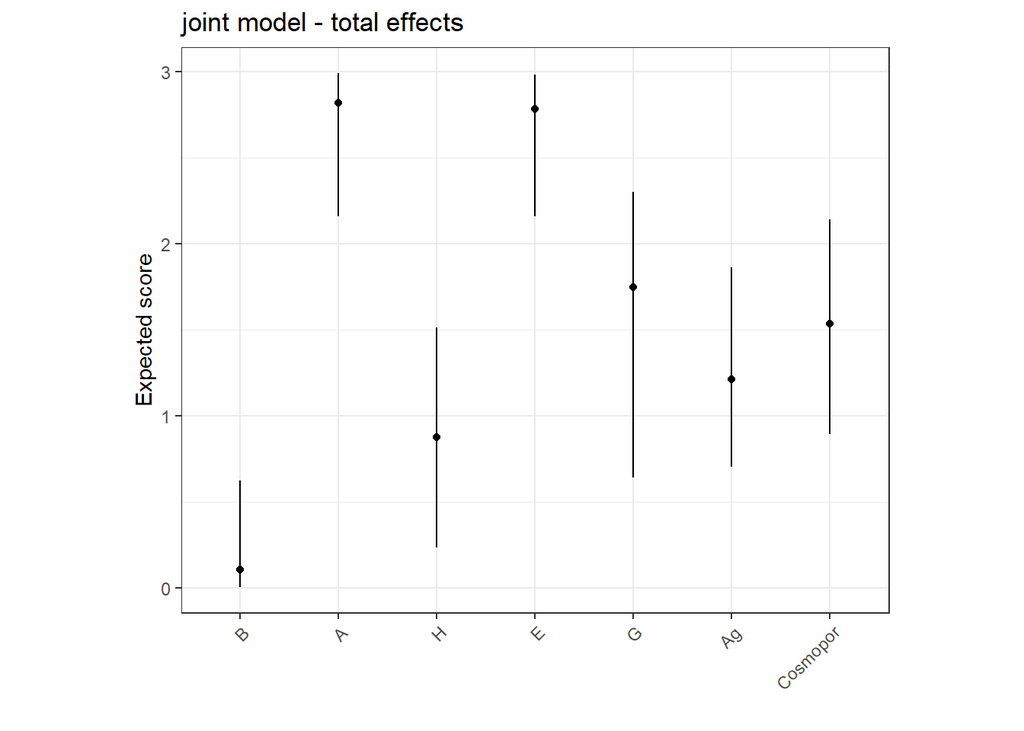

```r
# List of treatments you want to analyze
treatments <- c("A", "B", "E", "G", "H", "Ag", "Cosmopor")

# allocate results dataframe
total_eff<- tibble(
  treat = character(),
  mean_logCFU = numeric(),
  estimate = numeric(),
  lower = numeric(),
  upper = numeric()
)


for (t in treatments) {
  # predict logCFU for this treatment
  nd_t <- data1.2 |> mutate(treat = t)
  m_preds <- posterior_epred(fit_joint, resp = "logCFUmL2s",
                            newdata = nd_t,
                            re_formula = NA)
  mu_M_t <- colMeans(m_preds)

  # predict score using *this treatment's* mean CFU
  epred_t <- posterior_epred(fit_joint, resp = "score2",
                            newdata = nd_t |> mutate(log_CFU_mL2_s = mu_M_t),
                            re_formula = NA)
  mean_score_t <- calc_expected_score(epred_t)

  # summarize with median and 95% CrI
  results_t <- tibble(
    treat = t,
    mean_logCFU = median(mu_M_t),
    estimate = median(mean_score_t),
    lower = quantile(mean_score_t, 0.025),
    upper = quantile(mean_score_t, 0.975)
  )

  # Append to results
  total_eff <- bind_rows(total_eff, results_t)
}


p2_score_joint <-
  total_eff |>
  mutate(treat = factor(treat, levels = c("B", "A", "H", "E", "G", "Ag", "Cosmopor"))) |>
  ggplot() +
  geom_point(aes(x = treat,
                 y = estimate)) +
  geom_linerange(aes(x = treat,
                    ymin = lower,
                    ymax = upper)) +
  theme_bw() +
  #ylab("Expected latent wound score") +
  ylab("Expected score") +
  xlab("") +
  theme(aspect.ratio = 0.8,
        axis.text.x = element_text(angle = 45, vjust = 1, hjust=1))

p2_score_joint <- p2_score_joint + ggtitle("joint model - total effects")
# save(p2_score_joint, file = "p2_score_joint.RData")

p2_score_joint
```

##### Single ACAT model

- Note: A simpler alternative to get expectations is to use `(score2 ~ 1 + cs(treat) + (1 | batch / cage / ID))` - single ACAT
- To verify the robustness of the joint estimation, we compared the total treatment effects against independent single-process model (standalone ACAT)

**Open code**

```r
set.seed = 225

bm1.10.0 <- bf(score2 ~ 1 + cs(treat) + (1 | batch / cage / ID))

fit1.10.0  <- brm(bm1.10.0,
             data = data1.2,
             family = acat("probit"),
             warmup = 1000,
             iter = 4000,
             chains = 4,
             cores = 10,
             control = list(adapt_delta = 0.99, max_treedepth = 15),
             #save_all_pars = TRUE,
             sample_prior = TRUE,
                             prior = c(prior(normal(0, 1), class = Intercept),
                             prior(normal(0, 1), class = b, coef = "treatA"),
                             prior(normal(0, 1), class = b, coef = "treatAg"),
                             prior(normal(0, 1), class = b, coef = "treatB"),
                             prior(normal(0, 1), class = b, coef = "treatE"),
                             prior(normal(0, 1), class = b, coef = "treatG"),
                             prior(normal(0, 1), class = b, coef = "treatH")))

fit1.10.0 <- add_criterion(fit1.10.0, "loo")

save(fit1.10.0, file = "fit1.10.0.RData")
```

- plot the results (expectations) for the expected score from the simpler model `fit1.10.0` and compare with the joint model (`fit_joint`) results above.

**Open code**

```r
# ==============================================================================
# --- ORIGINAL DATA ---
# ==============================================================================
p0_score_simple <-
data1.2 |>
  group_by(treat, score2) |>
  mutate(treat = factor(treat, levels = c("B", "A", "H", "E", "G", "Ag", "Cosmopor"))) |>
  summarise(count = n()) |>
  ggplot(mapping = aes(x = treat, y = count, fill = factor(score2))) +
    geom_bar(stat = "identity") +
    ylab("Count") +
    xlab("") +
    theme_bw() +
    scale_fill_manual(values = c(mypal[3], mypal[7], mypal[5], mypal[1], mypal[8])) +
    labs(fill = "score2") +
    theme(aspect.ratio = 0.8,
        axis.text.x = element_text(angle = 45, vjust = 1, hjust=1),
        legend.position = "top"
  )
```

**Open code**

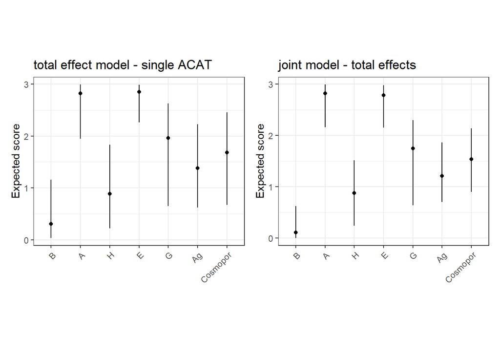

```r
# ==============================================================================
# --- ALL OIGINAL SCORES ---
# ==============================================================================
pred <- avg_predictions(fit1.10.0,
                       by = c("group", "treat"),
                       type = "response",
                       re_formula = NA,
                       conf_level = 0.95,
                       ndraws = 1000)

p1_score_simple <-
pred |>
  mutate(treat = factor(treat, levels = c("B", "A", "H", "E", "G", "Ag", "Cosmopor"))) |>
  ggplot() +
  geom_point(aes(x = treat,
                 y = estimate,
                 group = group,
                 color = group),
             position = position_dodge(width = 0.5)) +
  geom_errorbar(aes(x = treat,
                    ymin = conf.low,
                    ymax = conf.high,
                    group = group,
                    color = group),
                position = position_dodge(width = 0.5),
                width = 0.2) +
  theme_bw() +
  #ylab("Probability of observing score") +
  ylab("Probability") +
  xlab("") +
  scale_color_manual(values = c(mypal[3], mypal[7], mypal[5], mypal[1], mypal[8])) +
  theme(aspect.ratio = 0.8,
        axis.text.x = element_text(angle = 45, vjust = 1, hjust=1),
        legend.position = "none")


# ==============================================================================
# --- EXPECTED SCORE ---
# ==============================================================================
expected_scores <-
  get_draws(pred, shape = "long") |>
  mutate(score_val = as.numeric(as.character(group))) |>
  group_by(drawid, treat) |>
  summarise(exp_score = sum(draw * score_val), .groups = "drop")

expected_scores_sum <-
  expected_scores |>
  group_by(treat) |>
  reframe(
    median = median(exp_score),
    lower  = quantile(exp_score, 0.025),
    upper  = quantile(exp_score, 0.975)
  )

p2_score_simple <-
  expected_scores_sum |>
  mutate(treat = factor(treat, levels = c("B", "A", "H", "E", "G", "Ag", "Cosmopor"))) |>
  ggplot() +
  geom_point(aes(x = treat,
                 y = median)) +
  geom_linerange(aes(x = treat,
                    ymin = upper,
                    ymax = lower)) +
  theme_bw() +
  #ylab("Expected latent wound score") +
  ylab("Expected score") +
  xlab("") +
  theme(aspect.ratio = 0.8,
        axis.text.x = element_text(angle = 45, vjust = 1, hjust=1))

p2_score_simple <- p2_score_simple + ggtitle("total effect model - single ACAT")
save(p2_score_simple, file = "p2_score_simple.RData")

p2_score_joint <- p2_score_joint + ggtitle("joint model - total effects")
save(p2_score_joint, file = "p2_score_joint.RData")

p2_score_simple | p2_score_joint
```

#### 2.9.2.2 Contrasts

##### Joint model

- Based on joint model (Section 2.8)
- Each contrast was calculated separately using the code above (see Section 2.9.1)
- Specifically, we saved a `final_summary` (Section 2.9.1) for each contrast and then created a dataframe `total_effects` (in the chunk below) for the final graph

**Open code**

```r
# --- comparison of active treatments ---
B_G <- final_summary
save(B_G, file = "B_G.RData")

H_G <- final_summary
save(H_G, file = "H_G.RData")

B_H <- final_summary
save(B_H, file = "B_H.RData")

# --- comparison relative to native control ---
B_A <- final_summary
save(B_A, file = "B_A.RData")

H_E <- final_summary
save(H_E, file = "H_E.RData")

G_E <- final_summary
save(G_E, file = "G_E.RData")

# --- comparison relative to cosmpomor ---
B_Cosmopor <- final_summary
save(B_Cosmopor, file = "B_Cosmopor.RData")

H_Cosmopor <- final_summary
save(H_Cosmopor, file = "H_Cosmopor.RData")

G_Cosmopor <- final_summary
save(G_Cosmopor, file = "G_Cosmopor.RData")

Ag_Cosmopor <- final_summary
save(Ag_Cosmopor, file = "Ag_Cosmopor.RData")
```

**Open code**

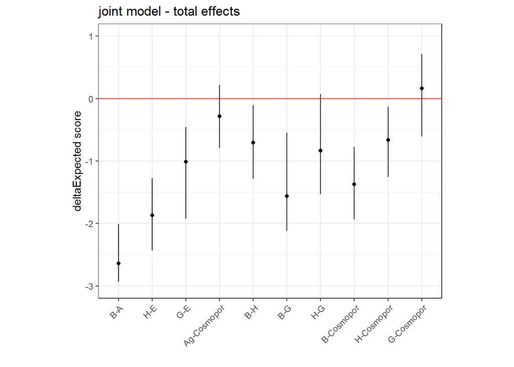

```r
load("C:/users/kindermann/Owncloud/4_biomedical_center/R2/1_bc/1_Projects/UOCHB_Rajman/Rmd/21082025_SAureus_Prevent_1az5/B_G.RData")
load("C:/users/kindermann/Owncloud/4_biomedical_center/R2/1_bc/1_Projects/UOCHB_Rajman/Rmd/21082025_SAureus_Prevent_1az5/H_G.RData")
load("C:/users/kindermann/Owncloud/4_biomedical_center/R2/1_bc/1_Projects/UOCHB_Rajman/Rmd/21082025_SAureus_Prevent_1az5/B_H.RData")
load("C:/users/kindermann/Owncloud/4_biomedical_center/R2/1_bc/1_Projects/UOCHB_Rajman/Rmd/21082025_SAureus_Prevent_1az5/B_A.RData")
load("C:/users/kindermann/Owncloud/4_biomedical_center/R2/1_bc/1_Projects/UOCHB_Rajman/Rmd/21082025_SAureus_Prevent_1az5/H_E.RData")
load("C:/users/kindermann/Owncloud/4_biomedical_center/R2/1_bc/1_Projects/UOCHB_Rajman/Rmd/21082025_SAureus_Prevent_1az5/G_E.RData")
load("C:/users/kindermann/Owncloud/4_biomedical_center/R2/1_bc/1_Projects/UOCHB_Rajman/Rmd/21082025_SAureus_Prevent_1az5/B_Cosmopor.RData")
load("C:/users/kindermann/Owncloud/4_biomedical_center/R2/1_bc/1_Projects/UOCHB_Rajman/Rmd/21082025_SAureus_Prevent_1az5/H_Cosmopor.RData")
load("C:/users/kindermann/Owncloud/4_biomedical_center/R2/1_bc/1_Projects/UOCHB_Rajman/Rmd/21082025_SAureus_Prevent_1az5/G_Cosmopor.RData")
load("C:/users/kindermann/Owncloud/4_biomedical_center/R2/1_bc/1_Projects/UOCHB_Rajman/Rmd/21082025_SAureus_Prevent_1az5/Ag_Cosmopor.RData")

comparison <- rep(c("B-G", "H-G", "B-H", "B-A", "H-E", "G-E", "B-Cosmopor", "H-Cosmopor", "G-Cosmopor", "Ag-Cosmopor"), each = 4)

total_effects <- bind_rows(B_G, H_G, B_H, B_A, H_E, G_E, B_Cosmopor, H_Cosmopor, G_Cosmopor, Ag_Cosmopor) |>
  mutate(comparison = comparison) |>
  filter(Parameter == "Total_Effect")

p3_score_joint  <-
total_effects |>
  mutate(comparison = factor(comparison, levels = c("B-A", "H-E", "G-E", "Ag-Cosmopor",
                                          "B-H", "B-G", "H-G", "B-Cosmopor",
                                          "H-Cosmopor", "G-Cosmopor"))) |>
  ggplot() +
  geom_point(mapping = aes(x = comparison, y = Estimate)) +
  geom_errorbar(mapping = aes(x = comparison, ymin = .lower, ymax = .upper),
                width = 0) +
  geom_hline(yintercept = 0, color = "red") +
  theme_bw() +
  ylab("deltaExpected score") +
  xlab("") +
  theme(axis.text.x = element_text(angle = 45, vjust = 1, hjust=1),
        aspect.ratio = 0.8) +
  ylim(-3, 1) +
  ggtitle("joint model - total effects")

p3_score_joint <- p3_score_joint + ggtitle("joint model - total effects")
save(p3_score_joint, file = "p3_score_joint.RData")

p3_score_joint
```

##### Single ACAT model

**Open code**

```r
# ==============================================================================
# --- EXPECTED SCORE / CONTRASTS ---
# ==============================================================================

# contrasts of interest
comparisons_to_make <- tribble(
  ~group1, ~group2,
  "B",     "G",
  "H",     "G",
  "B",     "H",
  "B",     "A",
  "B",     "Ag",
  "H",     "E",
  "G",     "E",
  "B",     "Cosmopor",
  "H",     "Cosmopor",
  "G",     "Cosmopor",
  "Ag",    "Cosmopor"
)

contrasts <-
  comparisons_to_make |>
  # Join group 1 values
  inner_join(expected_scores, by = c("group1" = "treat"), relationship = "many-to-many") |>
  rename(val1 = exp_score) |>
  # Join group 2 values for the SAME drawid
  inner_join(expected_scores, by = c("group2" = "treat", "drawid"), relationship = "many-to-many") |>
  rename(val2 = exp_score) |>
  mutate(diff = val1 - val2,
         comparison = paste0(group1, "-", group2)) |>
  group_by(comparison) |>
  reframe(
    median = median(diff),
    lower  = quantile(diff, 0.025),
    upper  = quantile(diff, 0.975)
  )

p3_score_simple <-
contrasts |>
  mutate(comparison = factor(comparison, levels = c("B-A", "H-E", "G-E", "Ag-Cosmopor",
                                          "B-H", "B-G", "B-Ag", "H-G", "B-Cosmopor",
                                          "H-Cosmopor", "G-Cosmopor"))) |>
  ggplot() +
  geom_point(aes(x = comparison,
                 y = median)) +
  geom_linerange(aes(x = comparison,
                    ymin = upper,
                    ymax = lower)) +
  geom_hline(yintercept = 0, color = "red") +
  theme_bw() +
  #ylab("Difference in expected latent wound score") +
  ylab("deltaExpected score") +
  xlab("") +
  theme(aspect.ratio = 0.8,
        axis.text.x = element_text(angle = 45, vjust = 1, hjust=1)) +
  theme(aspect.ratio = 0.8,
        axis.text.x = element_text(angle = 45, vjust = 1, hjust=1)) +
  ylim(-3, 1)
```

- plot the results (contrasts) for the expected score from the simpler model `fit1.10.0` and compare with the joint model (`fit_joint`) results above.

**Open code**

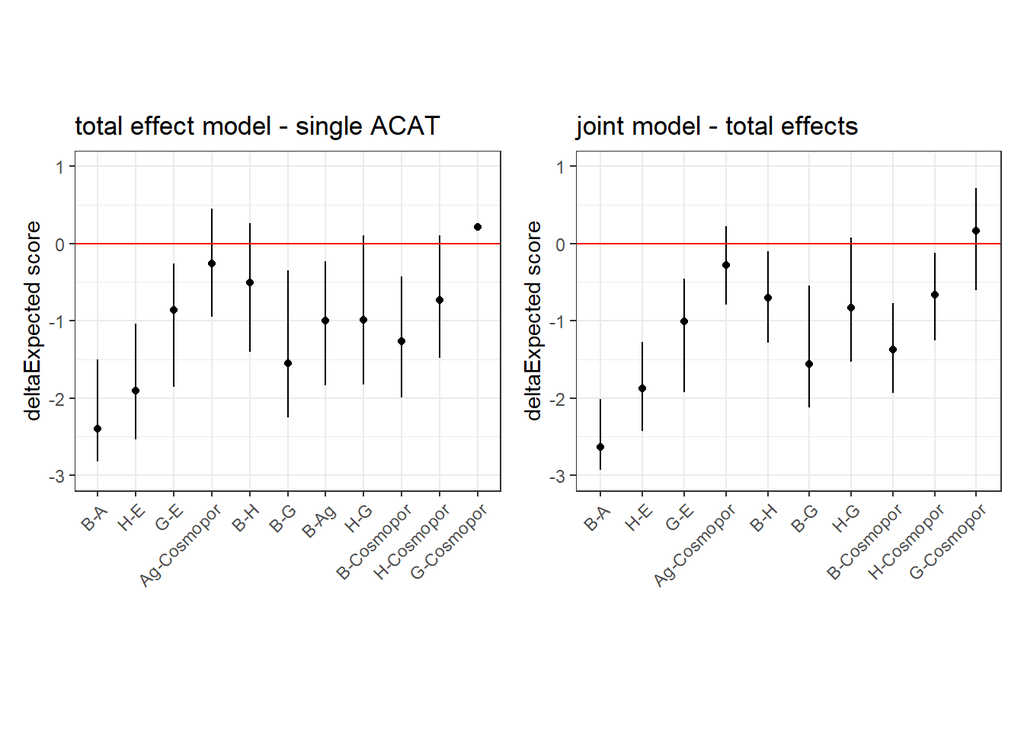

```r
p3_score_simple <- p3_score_simple + ggtitle("total effect model - single ACAT")
save(p3_score_simple, file = "p3_score_simple.RData")

p3_score_joint <- p3_score_joint + ggtitle("joint model - total effects")
save(p3_score_joint, file = "p3_score_joint.RData")

p3_score_simple | p3_score_joint
```

### 2.9.3 Does the treatment reduce bacterial load?

#### 2.9.3.1 Expectations

##### Joint model

- Based on joint model (Section 2.8)

**Open code**

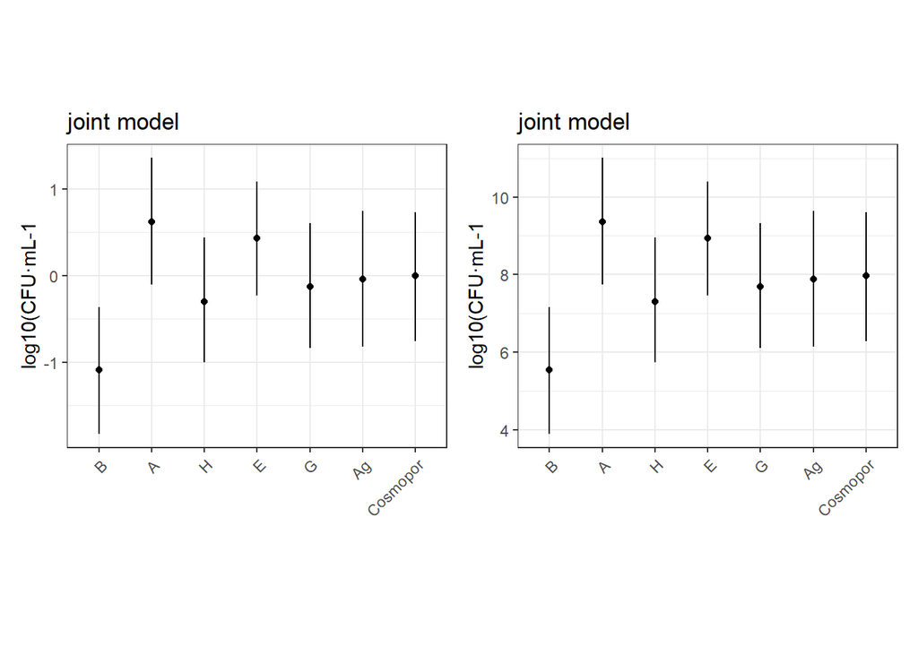

```r
# List of treatments you want to analyze
treatments <- c("A", "B", "E", "G", "H", "Ag", "Cosmopor")

# allocate results dataframe
total_eff<- tibble(
  treat = character(),
  estimate = numeric(),
  lower = numeric(),
  upper = numeric()
)


for (t in treatments) {
  # predict logCFU for this treatment
  nd_t <- data1.2 |> mutate(treat = t)
  m_preds <- posterior_epred(fit_joint, resp = "logCFUmL2s",
                            newdata = nd_t,
                            re_formula = NA)
  M_t <- m_preds[,1]

  # summarize with median and 95% CrI
  results_t <- tibble(
    treat = t,
    estimate = median(M_t),
    lower = quantile(M_t, 0.025),
    upper = quantile(M_t, 0.975)
  )

  # Append to results
  total_eff <- bind_rows(total_eff, results_t)
}


total_eff <-
  total_eff |>
  mutate(treat = factor(treat, levels = c("B", "A", "H", "E", "G", "Ag", "Cosmopor"))) |>
  #  calculate values on the original logCFU scale
  mutate(est = (estimate * log_CFU_mL2_sd) + log_CFU_mL2_mean,
         low = (lower * log_CFU_mL2_sd) + log_CFU_mL2_mean,
         up = (upper * log_CFU_mL2_sd) + log_CFU_mL2_mean)

p1_cfu_joint <-
  total_eff |>
  ggplot() +
  geom_point(aes(x = treat,
                 y = estimate)) +
  geom_linerange(aes(x = treat,
                    ymin = lower,
                    ymax = upper)) +
  theme_bw() +
  #ylab("Expected latent wound score") +
  ylab("log10(CFU·mL-1") +
  xlab("") +
  theme(aspect.ratio = 0.8,
        axis.text.x = element_text(angle = 45, vjust = 1, hjust=1))


p1_cfu_joint_original <-
  total_eff |>
  ggplot() +
  geom_point(aes(x = treat,
                 y = est)) +
  geom_linerange(aes(x = treat,
                    ymin = low,
                    ymax = up)) +
  theme_bw() +
  #ylab("Expected latent wound score") +
  ylab("log10(CFU·mL-1") +
  xlab("") +
  theme(aspect.ratio = 0.8,
        axis.text.x = element_text(angle = 45, vjust = 1, hjust=1))


p1_cfu_joint <- p1_cfu_joint + ggtitle("joint model")
save(p1_cfu_joint, file = "p1_cfu_joint.RData")

p1_cfu_joint_original <- p1_cfu_joint_original + ggtitle("joint model")
save(p1_cfu_joint_original, file = "p1_cfu_joint_original.RData")

p1_cfu_joint | p1_cfu_joint_original
```

##### Single Gaussian model

- Note: A simpler alternative is to use `log_CFU_mL2_s ~ 1 + treat + (1 | batch / cage / ID)` - single Gaussian
- To verify the robustness of the joint estimation, we compared the total treatment effects against independent single-process model (standalone Gaussian)

**Open code**

```r
pred <- avg_predictions(fit2.1.0,
                       by = c("treat"),
                       type = "response",
                       re_formula = NA,
                       conf_level = 0.95,
                       ndraws = 10000)

p1_cfu_simple  <-
pred |>
  mutate(treat = factor(treat, levels = c("B", "A", "H", "E", "G", "Ag", "Cosmopor"))) |>
  ggplot() +
  geom_point(aes(x = treat,
                 y = estimate)) +
  geom_errorbar(aes(x = treat,
                    ymin = conf.low,
                    ymax = conf.high),
                width = 0) +
theme_bw() +
ylab("log10(CFU·mL-1)") +
labs(x = "") +
theme(aspect.ratio = 0.8,
      axis.text.x = element_text(angle = 45, vjust = 1, hjust=1))
```

- plot the results (expectations) for the `log_CFU_mL2_s` from the simpler model `fit2.1.0` and compare with the joint model (`fit_joint`) results above.

**Open code**

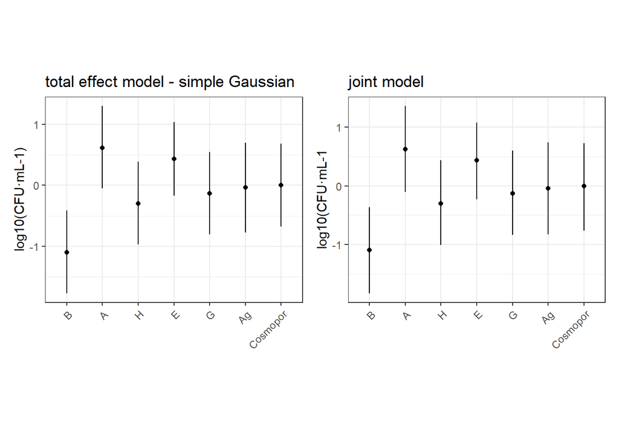

```r
p1_cfu_simple <- p1_cfu_simple + ggtitle("total effect model - simple Gaussian")
save(p1_cfu_simple, file = "p1_cfu_simple.RData")

p1_cfu_joint <- p1_cfu_joint + ggtitle("joint model")
save(p1_cfu_joint, file = "p1_cfu_joint.RData")

p1_cfu_simple | p1_cfu_joint
```

#### 2.9.3.2 Contrasts

##### Joint model

**Open code**

```r
# List of treatments you want to analyze
treatments <- c("A", "B", "E", "G", "H", "Ag", "Cosmopor")

# allocate results dataframe
total_eff<- tibble(
  estimate = numeric(),
)

for (t in treatments) {
  # predict logCFU for this treatment
  nd_t <- data1.2 |> mutate(treat = t)
  m_preds <- posterior_epred(fit_joint, resp = "logCFUmL2s",
                            newdata = nd_t,
                            re_formula = NA)
  M_t <- m_preds[,1]

  # summarize with median and 95% CrI
  results_t <- tibble(
    treat = t,
    estimate = M_t)

  # Append to results
  total_eff <- bind_rows(total_eff, results_t)
}


# column length for each treatment
length <-
  total_eff |>
  mutate(treat = as.factor(treat)) |>
  filter(treat == "A") |>
  summarise(treat = n())

# add id for each value
total_eff2 <-
  total_eff |>
  group_by(treat) |>
  mutate(id = 1:length$treat)

  # calculate comparisons
  contrasts_cfu <-
    comparisons_to_make |>
    # Join group 1 values
    inner_join(total_eff2, by = c("group1" = "treat"), relationship = "many-to-many") |>
    # Join group 2 values for the SAME drawid
    inner_join(total_eff2, by = c("group2" = "treat", "id"), relationship = "many-to-many") |>
    # calculate contrast
    mutate(diff = estimate.x - estimate.y,
           comparison = paste0(group1, "-", group2)) |>
    group_by(comparison) |>
    reframe(
      median = median(diff),
      lower  = quantile(diff, 0.025),
      upper  = quantile(diff, 0.975)
    ) |>
    # calculate values on the original logCFU scale
     mutate(change_est = median * log_CFU_mL2_sd,
             change_low = lower * log_CFU_mL2_sd,
             change_up = upper * log_CFU_mL2_sd)


# contrasts on standardized scale
p2_cfu_joint <-
  contrasts_cfu |>
  filter(comparison != "B-Ag") |>
  mutate(comparison = factor(comparison, levels = c("B-A", "H-E", "G-E", "Ag-Cosmopor",
                                          "B-H", "B-G", "H-G", "B-Cosmopor",
                                          "H-Cosmopor", "G-Cosmopor"))) |>
  ggplot() +
  geom_point(aes(x = comparison,
                 y = median)) +
  geom_linerange(aes(x = comparison,
                    ymin = lower,
                    ymax = upper)) +
  geom_hline(yintercept = 0, color = "red") +
  theme_bw() +
  #ylab("Expected latent wound score") +
  ylab("deltalog10(CFU·mL-1") +
  xlab("") +
  theme(aspect.ratio = 0.8,
        axis.text.x = element_text(angle = 45, vjust = 1, hjust=1)) +
  ggtitle("joint model")


# contrasts on original scale
p2_cfu_joint_original <-
  contrasts_cfu |>
  filter(comparison != "B-Ag") |>
  mutate(comparison = factor(comparison, levels = c("B-A", "H-E", "G-E", "Ag-Cosmopor",
                                          "B-H", "B-G", "H-G", "B-Cosmopor",
                                          "H-Cosmopor", "G-Cosmopor"))) |>
  ggplot() +
  geom_point(aes(x = comparison,
                 y = change_est)) +
  geom_linerange(aes(x = comparison,
                    ymin = change_low,
                    ymax = change_up)) +
  geom_hline(yintercept = 0, color = "red") +
  theme_bw() +
  #ylab("Expected latent wound score") +
  ylab("deltalog10(CFU·mL-1") +
  xlab("") +
  theme(aspect.ratio = 0.8,
        axis.text.x = element_text(angle = 45, vjust = 1, hjust=1)) +
  ggtitle("joint model")
```

##### Single Gaussian model

**Open code**

```r
pred_cfu <-
  get_draws(pred, shape = "long") |>
  group_by(drawid, treat)

contrasts <-
  comparisons_to_make |>
  inner_join(pred_cfu, by = c("group1" = "treat"), relationship = "many-to-many") |>
  inner_join(pred_cfu, by = c("group2" = "treat", "drawid"), relationship = "many-to-many") |>

  mutate(diff = draw.x - draw.y,
         comparison = paste0(group1, "-", group2)) |>
  group_by(comparison) |>
  reframe(
    median = median(diff),
    lower  = quantile(diff, 0.025),
    upper  = quantile(diff, 0.975)
  )


p2_cfu_simple  <-
contrasts |>
  mutate(comparison = factor(comparison, levels = c("B-A", "H-E", "G-E", "Ag-Cosmopor",
                                          "B-H", "B-G", "B-Ag", "H-G", "B-Cosmopor",
                                          "H-Cosmopor", "G-Cosmopor"))) |>
  ggplot() +
  geom_point(aes(x = comparison,
                 y = median)) +
  geom_linerange(aes(x = comparison,
                    ymin = upper,
                    ymax = lower)) +
  geom_hline(yintercept = 0, color = "red") +
  theme_bw() +
  # ylab("Difference in log10(CFU·mL-1)\n(standardized scale)") +
  ylab("deltalog10(CFU·mL-1)") +
  xlab("") +
  theme(aspect.ratio = 0.8,
        axis.text.x = element_text(angle = 45, vjust = 1, hjust=1))
```

- plot the results (contrasts) for the `log_CFU_mL2_s` from the simpler model `fit2.1.0` and compare with the joint model (`fit_joint`) results above.

**Open code**

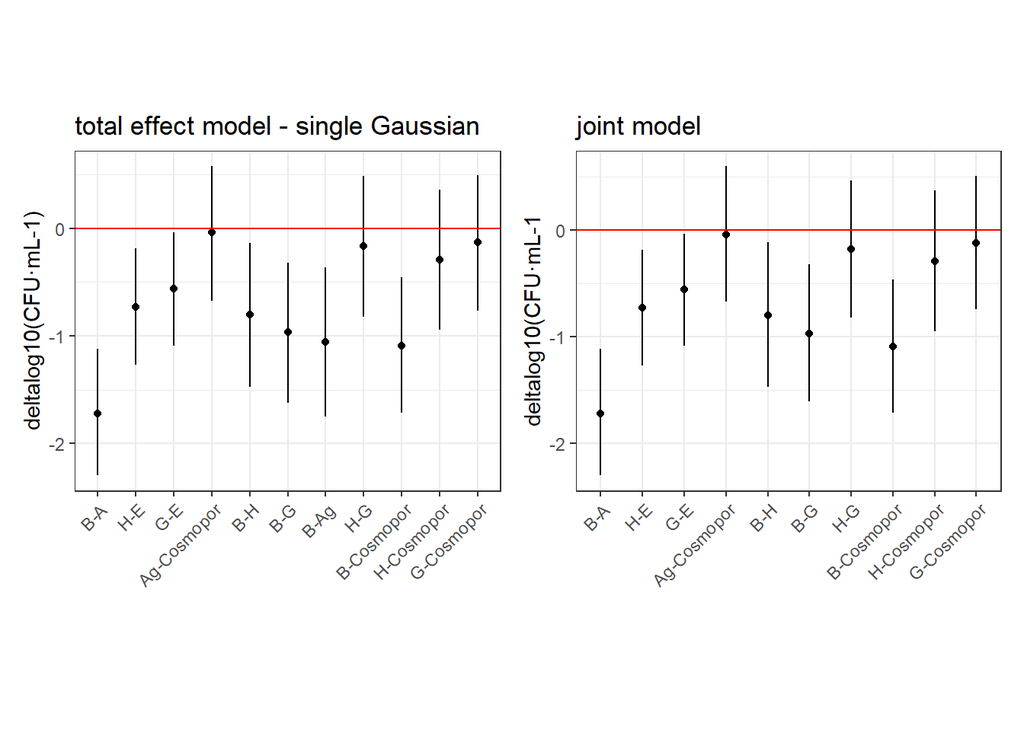

```r
p2_cfu_simple <- p2_cfu_simple + ggtitle("total effect model - single Gaussian")
save(p2_cfu_simple, file = "p2_cfu_simple.RData")

p2_cfu_joint <- p2_cfu_joint + ggtitle("joint model")
save(p2_cfu_joint, file = "p2_cfu_joint.RData")

p2_cfu_simple | p2_cfu_joint
```

## 2.10 Additional: Direct treatment effect

### 2.10.1 Single ACAT model

- Is there a direct tissue effect independent of CFU?

**Open code**

```r
bm1.11.0 <- bf(score2 ~ 1 + cs(treat) + log_CFU_mL2_s + (1 | batch / cage / ID))

fit1.11.0  <- brm(bm1.11.0,
             data = data1.2,
             family = acat("probit"),
             warmup = 1000,
             iter = 4000,
             chains = 4,
             cores = 10,
             control = list(adapt_delta = 0.99, max_treedepth = 15),
             #save_all_pars = TRUE,
             sample_prior = TRUE,
                             prior = c(prior(normal(0, 1), class = Intercept),
                             prior(normal(0, 1), class = b, coef = "treatA"),
                             prior(normal(0, 1), class = b, coef = "treatAg"),
                             prior(normal(0, 1), class = b, coef = "treatB"),
                             prior(normal(0, 1), class = b, coef = "treatE"),
                             prior(normal(0, 1), class = b, coef = "treatG"),
                             prior(normal(0, 1), class = b, coef = "treatH"),
                             prior(normal(0, 1), class = b, coef = "log_CFU_mL2_s")))

fit1.11.0 <- add_criterion(fit1.11.0, "loo")

save(fit1.11.0, file = "b_fit1.11.0.RData")
```

**Open code**

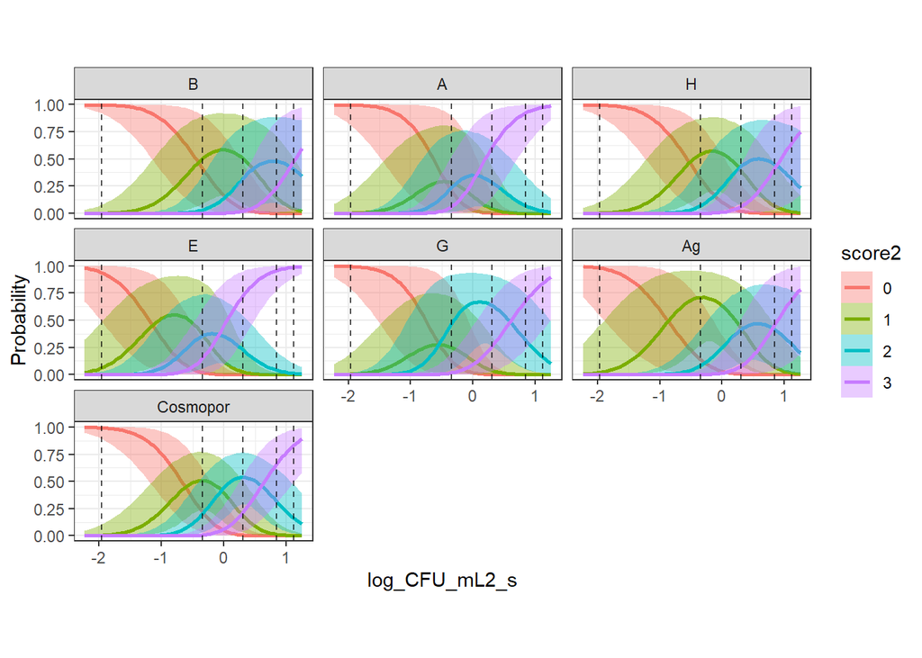

```r
# ==============================================================================
# --- EFFECT = CFU ---
# ==============================================================================
conditions <- data.frame(treat = c("B", "A", "H", "E", "G", "Ag", "Cosmopor"),
                         treat2 = c("B", "A", "H", "E", "G", "Ag", "Cosmopor"))
conditions <-
  conditions |>
  column_to_rownames(var = "treat2")

quantiles <- quantile(data1.2$log_CFU_mL2_s, probs = c(0.05, 0.25, 0.5, 0.75, 0.95))

ce <- conditional_effects(fit1.11.0, effects = "log_CFU_mL2_s",
                          conditions = conditions,
                          re_formula = NA,
                          prob = 0.95,
                          robust = TRUE,
                          method = "posterior_epred",
                          categorical = TRUE)

    plot(ce, plot = FALSE)[[1]] +
    geom_vline(xintercept = c(quantiles[1], quantiles[2], quantiles[3], quantiles[4], quantiles[5]),
                              linetype = "dashed", color = "black", alpha = 0.7) +
    theme_bw() +
    # scale_fill_manual(values = alpha(c(mypal[3], mypal[4], mypal[9], mypal[8]), 0.2)) +
    # scale_color_manual(values = alpha(c(mypal[7], mypal[6], mypal[10], mypal[1]), 1)) +
    theme(aspect.ratio = 0.5)
```

**Open code**

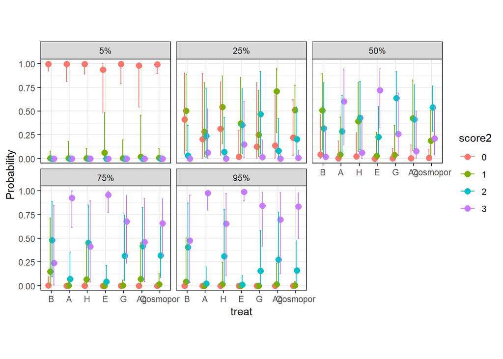

```r
# ==============================================================================
# --- EFFECT = TREAT ---
# ==============================================================================
conditions <- data.frame(log_CFU_mL2_s = c(quantiles[1], quantiles[2], quantiles[3], quantiles[4], quantiles[5]))
ce <- conditional_effects(fit1.11.0, effects = "treat",
                          conditions = conditions,
                          re_formula = NA,
                          prob = 0.95,
                          robust = TRUE,
                          method = "posterior_epred",
                          categorical = TRUE)

#change order of factor levels in plot
# Original order: 1Cosmopor | 2B | 3H | 4Ag | 5G | 6E | 7A
# Desired order: B | A | H | E | G | Ag | Cosmopor
# Desired order indexed: 2 | 7 | 3 | 6 | 5 | 4 | 1
ce$`treat:cats__`$effect1__ <-
  factor(ce$`treat:cats__`$effect1__, levels(ce$`treat:cats__`$effect1__)[c(2, 7, 3, 6, 5, 4, 1)])

plot(ce, plot = FALSE)[[1]] +
# scale_color_manual(values = c(mypal[3], mypal[7], mypal[5], mypal[8])) +
theme_bw() +
theme(aspect.ratio = 0.8)
```

# 3 For reproducibility

**Open code**

## References

Allaire, J. J., Charles Teague, Carlos Scheidegger, Yihui Xie, Christophe Dervieux, and Gordon Woodhull. 2025. *Quarto*. https://doi.org/10.5281/zenodo.5960048.

Bürkner, Paul-Christian. 2017. “Brms: An r Package for Bayesian Multilevel Models Using Stan.” *Journal of Statistical Software* 80 (August): 1–28. https://doi.org/10.18637/jss.v080.i01.

Bürkner, Paul-Christian, and Matti Vuorre. 2019. “Ordinal Regression Models in Psychology: A Tutorial.” *Advances in Methods and Practices in Psychological Science* 2 (1): 77–101. https://doi.org/10.1177/2515245918823199.

R Core Team. 2021. *R: A Language and Environment for Statistical Computing*. R Foundation for Statistical Computing. https://www.R-project.org/.

Stan Development Team. 2025. *RStan: The r Interface to Stan*. https://mc-stan.org/.

Wickham, Hadley, Mara Averick, Jennifer Bryan, et al. 2019. “Welcome to the Tidyverse.” *Journal of Open Source Software* 4 (43): 1686. https://doi.org/10.21105/joss.01686.

Zahradka, Ivan, Filip Tichanek, Maria Magicova, Istvan Modos, Ondrej Viklicky, and Vojtech Petr. 2024. “Morning Administration Enhances Humoral Response to SARS-CoV-2 Vaccination in Kidney Transplant Recipients.” *American Journal of Transplantation* 24 (9): 1690–97. https://doi.org/10.1016/j.ajt.2024.03.004.